# PEC2. Análisis de datos Ómicos.

Mª de la Vega Rodrigálvarez Chamarro

22 de diciembre, 2024

# 1 Resumen ejecutivo

A partir de los datos proporcionados por el estudio “**Expression data in Staphylococcus aureus-infected mice with linezolid and vancomycin treatment**” publicado el el 5 de junio de 2014 en Geo GSE38531 que contiene 35 muestras de ratón, se lleva a cabo un estudio para identificar los genes con expresión significativamente diferencial entre infectados por la enfermedad MRSA y los no infectados. Ambos grupos se han divido en tres donde un grupo no ha sido tratado, otro grupo ha sido tratado con Linezolid y otro grupo ha sido tratado con Vancomicina.

Tras el análisis de la información, se ha observado que en los tres grupos existen genes diferencialmente expresados entre el grupo de los infectados y los no infectados. Además, se ha visto que exite un conjunto de 52 genes que se comunes a los tres grupos de estudio que su expresión génica es diferente entre los infectados y los no infectados.

Con respecto al análisis biológico, se puede identicar que las expresiones génicas hacen referencia a la regulación del sistema inmunitario, pero se necesitaría un análisis más profundo para realizar una correcta interpretación.

# 2 Introducción y Objetivos

Dadas las 35 muestras de un modelo murino (ratón), el objetivo del estudio es encontrar los cambios en la expresión génica entre los ratones infectados y los no infectados en los siguientes grupos:

- Infectados contra no infectados y que no han recibido ningún tratamiento.
- Infectados contra no infectados y que hayan sido tratados con Linezolid.
- Infectados contra no infectados y que hayan sido tratados con Vancomicima.

Finalmente, con los genes seleccionados se tratará de identificar una significación biológica a los diferentes conjuntos de genes identificados en los tres estudios. Finalmente, se estudiará que genes se encuentran significamente representados en los tres grupos y se les dará un significación biológica.

# 3 Métodos

Para cada individuo se ha tomado un total de 1004004 muestras con el objeto de analizar la expresión génica de los diferentes individuos ante las diferentes condiciones generadas. Antes de proceder con la comparación de la expresión génica de los diferentes grupos, se realiza un análisis exploratorio de los mismos para verificar su calidad. Una vez se han verificado los diferentes datos y se han hecho las transformaciones necesarias, se procede con el análisis de la expresión génica.

Para realizar el análisis exploratorio de los datos y determinar su calidad se han realizado diversos estudios de comparación (boxplot) y de clasificación para ver si hay algún dato anormal en la muestra. Además, se ha realizado un análisis de componentes principales donde se ve una clara separación en las expresiones génicas de aquellas muestras que han sido infectadas de aquellas de las que no. Aunque según el tratamiento administrado, las diferencias son menos claras.

A continuación, se ha realizado un filtrado de genes donde se han eliminado aquellos que tienen menor variabilidad. El criterio seguido para el filtrado ha sido eliminando todos aquellos genes que su variabilidad se encuentra por debajo del 90% del porcentaje de cuartiles. Este filtrado ha reducido bastante la muestra quedando un conjunto de 2048 genes que analizar.

Para poder realizar el estudio de contrastes, ha sido necesario construir una matriz de diseño donde se han generado 6 grupos diferentes y se ha creado la matriz de contraste para poder estudiar la variación de la expresión génica entre infectados y no infectados en función del tratamiento recibido.

Se han generado 3 listas de genes y se ha mostrado un mapa de calor por cada grupo. En los mapas de calor se ha visto que sí que existe una diferencia en la expresión génica entre los grupos de infectados y los no infectados. En un diagrama de Venn se puede ver las coincidencias en el número de genes que hay en común entre los diferentes grupos.

Una vez que los genes han sido identificados, se procede a su anotación usando la base de datos “mouse4302.db” de Bioconductor que contiene los genes anotados de las sondas proporcionadas por Affymetrix Mouse Genome 430 2.0 (chip mouse4302). Los genes han sido anotados con los códigos de Symbol, Ensembl y EntrezID.

Una vez que los genes han sido anotados, se han buscado los diferentes *pathways* biologicamente significativos dentro de la Gene Ontology (GO) que contiene los genes anotados. Para ello se ha utilizado el paquete *clusterProfiler* de *BioConductor*.

# 4 Resultados

En esta sección, se trabaja con los datos para encontrar las diferentes expresiones génicas desde que se analiza la calidad de los mismos hasta que se realiza el análisis de significación biológica.

*Análisis exploratorio y control de calidad*

Antes de realizar el análisis de los datos, se procede a realizar un estudio exploratorio de los datos y un control de calidad de los mismos para ver si existe alguna anormalidad en los datos o si es necesario alguna transformación de los mismos.

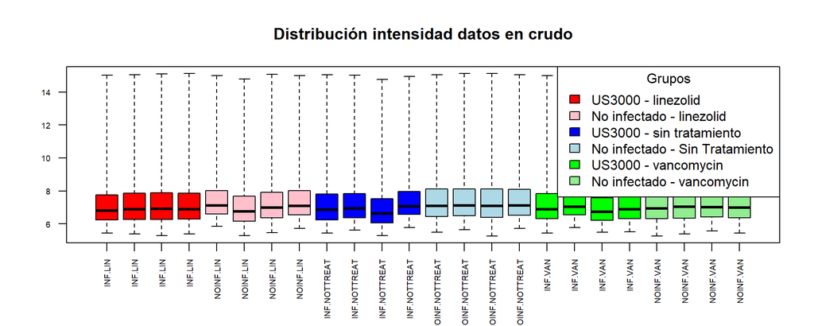

Intensidad distribución muestras

- Un primer grupo que contiene 2 muestras *GSM944840* y *GSM944856* las cuales una ha sido infectada por el virus y otra que no lo ha sido. Se puede observar en el diagrama de cajas, el rango de valores de las intensidades es menor y también la mediana.
- Existe un segundo grupo, mucho más extenso, que contiene 11 muestras y que está formado por todas aquellas muestras que no han sido infectadas por el virus.
- Y por último, un tercer grupo que contiene todas aquellas muestras que sí que han sido infectadas con el virus.

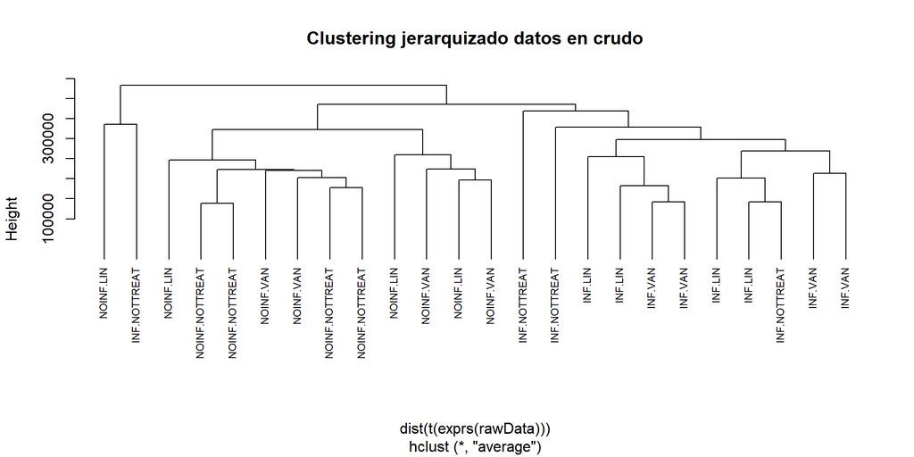

Clusterización

Como se puede observar, excepto 2 muestras que han sido clasificadas de forma independiente, se han creado dos grupos, uno que contiene todas aquellas muestras que han sido infectadas y otro grupo con aquellas que no lo han sido.

Finalmente, se procede a realizar un análisis de componentes (PCA) con el objeto de reducir la dimensionalidad de la muestra y observar como se agrupan y explican las diferentes muestras.

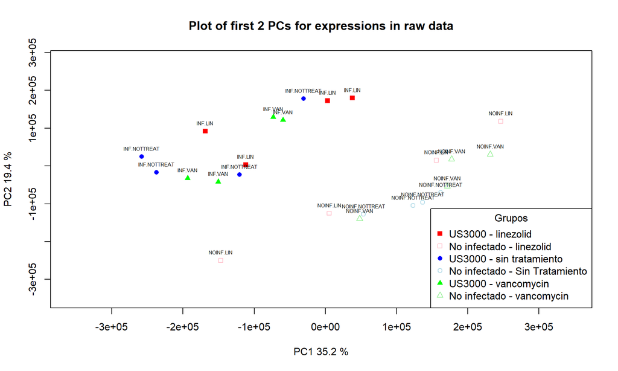

Análisis PCA

Para un análisis de calidad de los datos se ha ejecutado el paquete de R *arrayQualityMetrics*, el cuál ha sido ejecutado y cuyos resultados se pueden ver en el *Anexo I. Calidad de los datos* que se adjunta junto al presente informe y donde se pueden ver unos resultados similares.

Antes de continuar con el análisis y el estudio de los datos se procederá a la normalización de los datos y que todos los valores se encuentren en el mismo rango de valores utilizando el método de RMA.

Como resultado de la normalización, se ha obtenido un *ExpressionSet* formado por 45101 sondas o filas y 24 columnas, una por cada muestra. Se puede encontrar el fichero normalizado en NormData.txt.

*Filtrado de los datos*

Una vez que los datos han sido normalizados, se procede a realizar una selección de genes para facilitar su estudio. Se va a proceder a eliminar aquellos genes los cuales tienen poca variabilidad ya que, al variar poco entre los grupos es probable que no sean candidatos para encontrar diferencias y así, poder identificar que genes tienen una mayor representación biológica.

En este estudio se procederá a seleccionar el 10% de las sondas que presentan una mayor variabilidad.

Para poder realizar el filtrado de los datos, hay que indicar la anotación del ExpressionSet. Tal y como índica en el estudio del que los datos han sido obtenidos, la plataforma utilizada ha sido “Affymetrix Mouse430_2 Array annotation data (chip mouse4302)” por lo que la librería de anotación a usar de *BioConductor* ha sido “mouse4302.db”.

El punto de corte del filtrado se ha fijado en 0.9 con el objeto de tener el 10%, en base a cuartiles, de las sondas con más variabilidad e independientemente de que tengan anotación *Entrez* o no. El resultado de este filtrado hace que haya un total de *2048* genes más representativos con los que llevar a cabo el análisis de expresión génica. Se han eliminado 24561 elementos duplicados, 18428 elementos de baja variabilidad y 64 *features* excluidas.

Una vez filtrados los datos, se obtendrá una matriz filtrada para proceder con la selección de genes.

*Construcción de la matriz de diseño y contrastes*

Para construir la matriz de diseño, hace falta información acerca de los factores experimentales o los grupos del estudio.

En este conjunto de muestras,tras la selección de las mismas, existen 12 ratones que han sido infectados con el virus *Staphylococcus aureas* y 12 ratones no infectados, considerados de control. Dentro de cada grupo, 4 ratones no han sido tratados con ningún medicamento, 4 ratones han sido tratados con linezolid y 4 con vancomycin, por lo que existen dos factores. Los seis grupos que existen son:

- Grupo 1. Infectado y tratado con Linezolid (INF.LIN)
- Grupo 2. No infectado y tratado con Linezolid (NOINF.LIN)
- Grupo 3. Infectado y sin ningún tratamiento. (INF.NOTTREAT)
- Grupo 4. No infectado y sin ningún tratamiento. (NOINF.NOTTREAT)
- Grupo 5. Infectado y tratado con Vancomycin. (INF.VAN)
- Grupo 6. No infectado y tratado con vancomycin. (NOINF.VAN)

Una vez definidos los grupos se proceder a construir la matriz de diseño que quedará de la siguiente forma:

Matriz de diseño

|  | INF LIN | NOINF LIN | INF NOTTREAT | NOINF NOTTREAT | INF VAN | NOINF VAN |
| --- | --- | --- | --- | --- | --- | --- |
| INF.LIN | 1 | 0 | 0 | 0 | 0 | 0 |
| INF.LIN | 1 | 0 | 0 | 0 | 0 | 0 |
| INF.LIN | 1 | 0 | 0 | 0 | 0 | 0 |
| INF.LIN | 1 | 0 | 0 | 0 | 0 | 0 |
| NOINF.LIN | 0 | 1 | 0 | 0 | 0 | 0 |
| NOINF.LIN | 0 | 1 | 0 | 0 | 0 | 0 |
| NOINF.LIN | 0 | 1 | 0 | 0 | 0 | 0 |
| NOINF.LIN | 0 | 1 | 0 | 0 | 0 | 0 |
| INF.NOTTREAT | 0 | 0 | 1 | 0 | 0 | 0 |
| INF.NOTTREAT | 0 | 0 | 1 | 0 | 0 | 0 |
| INF.NOTTREAT | 0 | 0 | 1 | 0 | 0 | 0 |
| INF.NOTTREAT | 0 | 0 | 1 | 0 | 0 | 0 |
| NOINF.NOTTREAT | 0 | 0 | 0 | 1 | 0 | 0 |
| NOINF.NOTTREAT | 0 | 0 | 0 | 1 | 0 | 0 |
| NOINF.NOTTREAT | 0 | 0 | 0 | 1 | 0 | 0 |
| NOINF.NOTTREAT | 0 | 0 | 0 | 1 | 0 | 0 |
| INF.VAN | 0 | 0 | 0 | 0 | 1 | 0 |
| INF.VAN | 0 | 0 | 0 | 0 | 1 | 0 |
| INF.VAN | 0 | 0 | 0 | 0 | 1 | 0 |
| INF.VAN | 0 | 0 | 0 | 0 | 1 | 0 |
| NOINF.VAN | 0 | 0 | 0 | 0 | 0 | 1 |
| NOINF.VAN | 0 | 0 | 0 | 0 | 0 | 1 |
| NOINF.VAN | 0 | 0 | 0 | 0 | 0 | 1 |
| NOINF.VAN | 0 | 0 | 0 | 0 | 0 | 1 |

El objetivo del estudio es comparar las diferencias en las expresiones génicas de los ratones infectados y de los no infectados dentro del grupo del tratamiento en el que se encuentran. Para ello, se construirá la matriz de contrastes de la siguiente manera:

- INF.LIN vs NOINF.LIN
- INF.NOTTREAT vs NOINF.NOTTREAT
- INF.VAN vs NOINF.VAN

Matriz de contraste

|  | LIN_INF_NOINF | NOTTREAT_INF_NOINF | VAN_INF_NOINF |
| --- | --- | --- | --- |
| INF.LIN | 1 | 0 | 0 |
| NOINF.LIN | -1 | 0 | 0 |
| INF.NOTTREAT | 0 | 1 | 0 |
| NOINF.NOTTREAT | 0 | -1 | 0 |
| INF.VAN | 0 | 0 | 1 |
| NOINF.VAN | 0 | 0 | -1 |

*Obtención de las listas de genes diferencialmente expresados para cada comparación*

Una vez definida la matriz de diseño y los contrastes, se procede a estimar el modelo y los contrastes, así como las pruebas de significación que ayudarán a decidir, para cada gen y para cada comparación, si pueden considerarse de expresión diferencial. Para ello se ha usado el paquete *limma*.

Una vez que se ha calculado el modelo, se obtiene para cada uno de los contrastes los genes más significativos. El punto de corte se establece con el p-valor, seleccionando únicamente aquella de lista de genes cuyo p-valor es menor de 0.05 y el mínimo cambio de pliegues es igual a 2.

Para aquellos ratones que han sido tratados con Linezolid se han identificado 188 genes. En la siguiente tabla se muestra una representación de los primeros genes más significativos.

Genes diferencialmente expresados LINEZOLID

|  | logFC | AveExpr | t | P Value | adj P Val | B |
| --- | --- | --- | --- | --- | --- | --- |
| 1421262_at | 6.157126 | 7.175233 | 16.81011 | 0 | 0 | 21.47320 |
| 1427747_a_at | 4.952167 | 10.693149 | 14.02125 | 0 | 0 | 18.09290 |
| 1419681_a_at | 4.798082 | 7.386037 | 13.26956 | 0 | 0 | 17.07058 |
| 1440865_at | 3.362591 | 11.173847 | 12.92250 | 0 | 0 | 16.58065 |
| 1422953_at | 2.840405 | 11.192299 | 12.31129 | 0 | 0 | 15.68883 |
| 1448562_at | 4.413814 | 7.599334 | 12.03517 | 0 | 0 | 15.27333 |

Además, como se puede ver en el mapa de calor, se puede ver que hay una clara diferencia entre el grupo de infectados (rojo, azul, verde) y los no infectados (rosa, azul claro, verde claro).

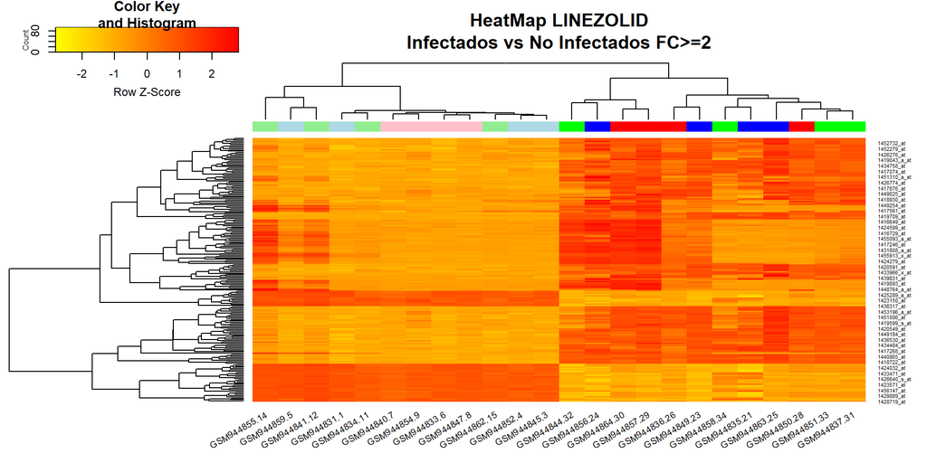

Mapa de calor. Linezolid Infectados vs No Infectados

Para aquellos ratones que no han sido tratados, se ha identificado un total de 236 genes diferencialmente expresados.

Genes diferencialmente expresados No Tratados

|  | logFC | AveExpr | t | P Value | adj P Val | B |
| --- | --- | --- | --- | --- | --- | --- |
| 1421262_at | 7.202325 | 7.175233 | 19.66370 | 0 | 0 | 24.64100 |
| 1427747_a_at | 6.237323 | 10.693149 | 17.65996 | 0 | 0 | 22.57310 |
| 1422953_at | 3.851164 | 11.192299 | 16.69227 | 0 | 0 | 21.48698 |
| 1440865_at | 4.077956 | 11.173847 | 15.67166 | 0 | 0 | 20.27224 |
| 1418722_at | 6.033845 | 10.981607 | 15.32034 | 0 | 0 | 19.83648 |
| 1429387_at | -2.125765 | 6.421327 | -14.74724 | 0 | 0 | 19.10509 |

En el mapa de calor, también se puede ver una clara diferencia entre aquellos que están infectados y no están infectados.

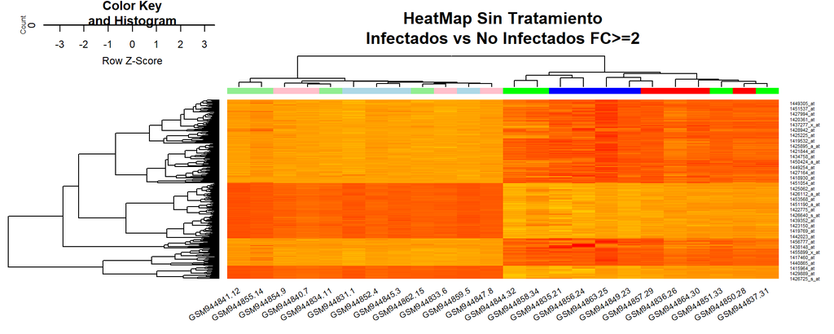

Mapa de calor. No tratados. Infectados vs No Infectados

Para aquellos ratones que han sido tratados con Vancomycin, se ha identificado un total de 139 genes diferencialmente expresados.

Genes diferencialmente expresados. Vancomycina.

|  | logFC | AveExpr | t | P Value | adj P Val | B |
| --- | --- | --- | --- | --- | --- | --- |
| 1421262_at | 6.636277 | 7.175233 | 18.11828 | 0 | 0 | 22.94343 |
| 1427747_a_at | 5.162365 | 10.693149 | 14.61639 | 0 | 0 | 18.89884 |
| 1419681_a_at | 5.211970 | 7.386037 | 14.41420 | 0 | 0 | 18.63698 |
| 1440865_at | 3.638019 | 11.173847 | 13.98098 | 0 | 0 | 18.06410 |
| 1418722_at | 5.213168 | 10.981607 | 13.23659 | 0 | 0 | 17.04063 |
| 1436419_a_at | -2.327081 | 8.574273 | -12.36159 | 0 | 0 | 15.77012 |

En el mapa de calor, también se puede ver una clara diferencia entre aquellos que están infectados y no están infectados.

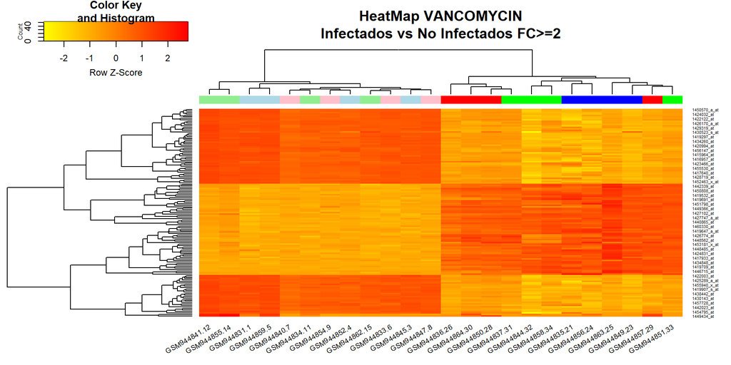

Las tablas completas de genes expresados diferencialmente se pueden ver de forma completa en el **Apendice A**.

A continuación, se puede ver una tabla con el número de genes que tienen una alta significancia, aquellos que no tienen significancia y los que tienen una baa significancia por estudio realizado.

Número de Genes diferencialmente expresados

|  | **Linezolid** | **Sin Tratamiento** | **Vancomicina** |
| --- | --- | --- | --- |
| **Alta Significancia (UP)** | 150 | 146 | 61 |
| **Sin Significancia** | 1860 | 1812 | 1909 |
| **Baja Significancia (DOWN)** | 38 | 90 | 78 |

Finalmente, se procede a comparar la lista de genes expresados diferencialmente más significativos de los tres contrastes realizados a través de un diagrama de VENN donde se puede observar que de todos los genes diferencialmente expresados 52, son relevantes en los 3 grupos.

Genes comunes en los diferentes estudios

| Linezolid | Sin Tratamiento | Vancomizina | N Comunes |
| --- | --- | --- | --- |
| 0 | 0 | 0 | 1840 |
| 0 | 0 | 1 | 0 |
| 0 | 1 | 0 | 49 |
| 0 | 1 | 1 | 9 |
| 1 | 0 | 0 | 62 |
| 1 | 0 | 1 | 0 |
| 1 | 1 | 0 | 36 |
| 1 | 1 | 1 | 52 |

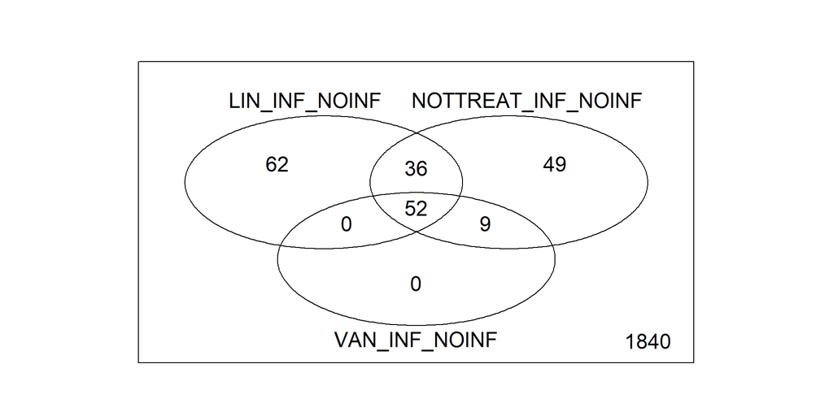

Diagrama de Venn. Genes comunes

Según el diagrama de Venn se puede ver que existen 52 genes que son comunes a los 3 grupos, hay 88 (36 + 52) genes que son comunes a aquellos que han sido tratados con Linezolid y no tienen ningún tratamiento. Hay 52 genes que coinciden en los tratados con linezolid y vancomizina (coincidiendo con la intersección de los 3 grupos) y que hay 61 genes (52 + 9) que intersectan con aquellos que han recibido como tratamiento vancomizina y no han recibido tratamiento.

También se puede observar que para aquellos que han recibido tratamiento con vancomizina no tiene genes expresados diferencialmente únicamente para ese grupo, ya que son compartidos con el resto de grupos, por lo que se podría decir, que el tratamiento con vancomizina no tiene un efecto diferente al de resto de grupos. También se podría llegar a la conclusión que el tratamiento más efectivo o que más diferencias muestra es el linezolid.

*Anotación de los genes*

Se han obtenido las listas de los genes más significativos en los diferentes estudios de contrastes. En todas las tablas, los genes se encuentran anotados con el identificador del proveedor del análisis, que en este ocasión se ha realizado con el chip de Affymetrix *mouse 4302*. Se anotan los genes con bases de datos públicas tales como “Symbol”, “EntrezID” o “EnsemblID” para poder realizar los estudios de relevancia biológica.

Principales genes diferencialmente expresados. Linezolid

| PROBEID | SYMBOL | GENENAME | ENSEMBL | ENTREZID |
| --- | --- | --- | --- | --- |
| 1415897_a_at | Mgst1 | microsomal glutathione S-transferase 1 | ENSMUSG00000008540 | 56615 |
| 1415994_at | Cyp2e1 | cytochrome P450, family 2, subfamily e, polypeptide 1 | ENSMUSG00000025479 | 13106 |
| 1416025_at | Fgg | fibrinogen gamma chain | ENSMUSG00000033860 | 99571 |
| 1416332_at | Cirbp | cold inducible RNA binding protein | ENSMUSG00000045193 | 12696 |
| 1416625_at | Serping1 | serine (or cysteine) peptidase inhibitor, clade G, member 1 | ENSMUSG00000023224 | 12258 |
| 1416649_at | Ambp | alpha 1 microglobulin/bikunin precursor | ENSMUSG00000028356 | 11699 |
| 1416676_at | Kng1 | kininogen 1 | ENSMUSG00000022875 | 16644 |
| 1416677_at | Apoh | apolipoprotein H | ENSMUSG00000000049 | 11818 |
| 1416729_at | Plg | plasminogen | ENSMUSG00000059481 | 18815 |
| 1417063_at | C1qb | complement component 1, q subcomponent, beta polypeptide | ENSMUSG00000036905 | 12260 |

Principales genes diferencialmente expresados. Sin tratamiento

| PROBEID | SYMBOL | GENENAME | ENSEMBL | ENTREZID |
| --- | --- | --- | --- | --- |
| 1415897_a_at | Mgst1 | microsomal glutathione S-transferase 1 | ENSMUSG00000008540 | 56615 |
| 1415964_at | Scd1 | stearoyl-Coenzyme A desaturase 1 | ENSMUSG00000037071 | 20249 |
| 1416021_a_at | Fabp5 | fatty acid binding protein 5, epidermal | ENSMUSG00000027533 | 16592 |
| 1416107_at | Nsg2 | neuron specific gene family member 2 | ENSMUSG00000020297 | 18197 |
| 1416111_at | Cd83 | CD83 antigen | ENSMUSG00000015396 | 12522 |
| 1416125_at | Fkbp5 | FK506 binding protein 5 | ENSMUSG00000024222 | 14229 |
| 1416381_a_at | Prdx5 | peroxiredoxin 5 | ENSMUSG00000024953 | 54683 |
| 1416514_a_at | Fscn1 | fascin actin-bundling protein 1 | ENSMUSG00000029581 | 14086 |
| 1416871_at | Adam8 | a disintegrin and metallopeptidase domain 8 | ENSMUSG00000025473 | 11501 |
| 1416957_at | Pou2af1 | POU domain, class 2, associating factor 1 | ENSMUSG00000032053 | 18985 |

Principales genes diferencialmente expresados. Vancomizina

| PROBEID | SYMBOL | GENENAME | ENSEMBL | ENTREZID |
| --- | --- | --- | --- | --- |
| 1415964_at | Scd1 | stearoyl-Coenzyme A desaturase 1 | ENSMUSG00000037071 | 20249 |
| 1416111_at | Cd83 | CD83 antigen | ENSMUSG00000015396 | 12522 |
| 1416630_at | Id3 | inhibitor of DNA binding 3 | ENSMUSG00000007872 | 15903 |
| 1416809_at | Cyp3a11 | cytochrome P450, family 3, subfamily a, polypeptide 11 | ENSMUSG00000056035 | 13112 |
| 1416957_at | Pou2af1 | POU domain, class 2, associating factor 1 | ENSMUSG00000032053 | 18985 |
| 1417025_at | H2-Eb1 | histocompatibility 2, class II antigen E beta | ENSMUSG00000060586 | 14969 |
| 1417074_at | Ceacam10 | CEA cell adhesion molecule 10 | ENSMUSG00000054169 | 26366 |
| 1417268_at | Cd14 | CD14 antigen | ENSMUSG00000051439 | 12475 |
| 1417290_at | Lrg1 | leucine-rich alpha-2-glycoprotein 1 | ENSMUSG00000037095 | 76905 |
| 1417640_at | Cd79b | CD79B antigen | ENSMUSG00000040592 | 15985 |

En la siguiente lista se ven los genes representados significativamente que son comunes a los tres estudios.

Principales genes diferencialmente expresados. Comunes

| PROBEID | SYMBOL | GENENAME | ENSEMBL | ENTREZID |
| --- | --- | --- | --- | --- |
| 1436530_at | Wfdc17 | WAP four-disulfide core domain 17 | ENSMUSG00000069792 | 100034251 |
| 1418204_s_at | Aif1 | allograft inflammatory factor 1 | ENSMUSG00000024397 | 11629 |
| 1460330_at | Anxa3 | annexin A3 | ENSMUSG00000029484 | 11745 |
| 1417268_at | Cd14 | CD14 antigen | ENSMUSG00000051439 | 12475 |
| 1451537_at | Chi3l1 | chitinase 3 like 1 | ENSMUSG00000064246 | 12654 |
| 1419764_at | Chil3 | chitinase-like 3 | ENSMUSG00000040809 | 12655 |
| 1427256_at | Vcan | versican | ENSMUSG00000021614 | 13003 |
| 1417876_at | Fcgr1 | Fc receptor, IgG, high affinity I | ENSMUSG00000015947 | 14129 |
| 1422953_at | Fpr2 | formyl peptide receptor 2 | ENSMUSG00000052270 | 14289 |
| 1450808_at | Fpr1 | formyl peptide receptor 1 | ENSMUSG00000045551 | 14293 |

*Análisis de la significación biológica*

Una vez que los genes han sido anotados, se realiza el estudio de significación biológica. Para ello se consulta en la base de datos *Gene Ontology* (GO) con el objeto de realizar diferentes análisis estadísticos para identificar que anotaciones tienen una frecuencia sorprendentemente más alta.

Por cada estudio de contraste realizado se va a mostrar un gráfico de barras donde se mostrará los *pathways* más enriquecidos en cada estudio de contraste y una red de genes relacionando como los *pathways* están relacionados unos con otros.

*Significación biológica - Infectados y no Infectados para LINEZOLID*

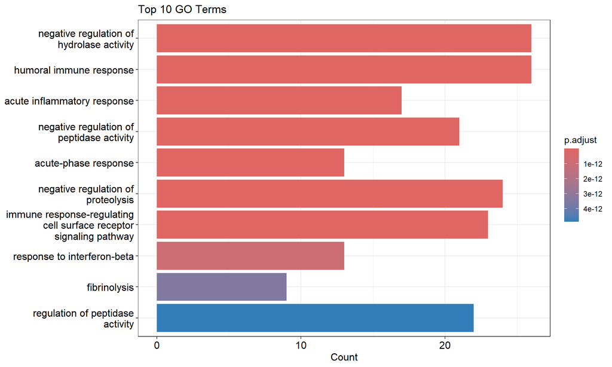

Gráficas significancia biológica LINEZOLID

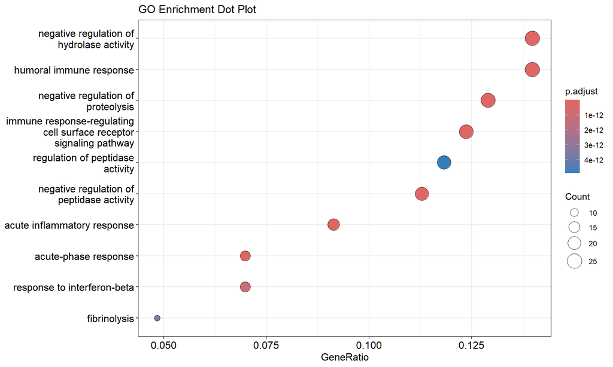

Gráficas significancia biológica LINEZOLID

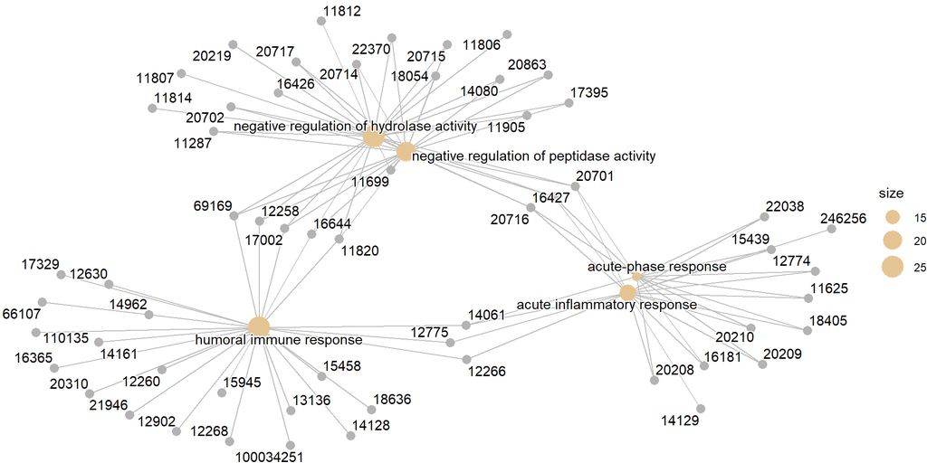

Red de genes expresados diferencialmente LINEZOLID

En base a estos gráficos, la expresión génica diferencial parece que es importante en mayor medida para:

- Regulación negativa de la actividad hidrolasa
- Respuesta inmunitaria humoral
- Regulación negativa de la proteólisis
- Regulación negativa de la actividad peptidasa

*Significación biológica - Infectados y no Infectados para SIN TRATAMIENTO*

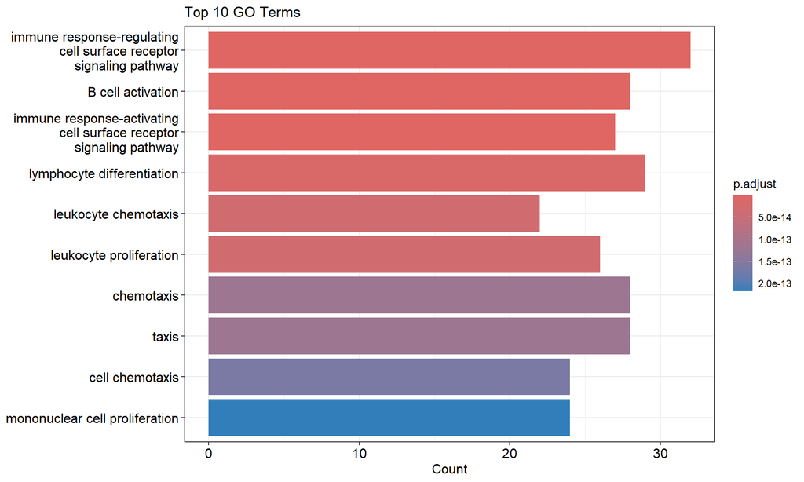

Gráficas significancia biológica SIN TRATAMIENTO

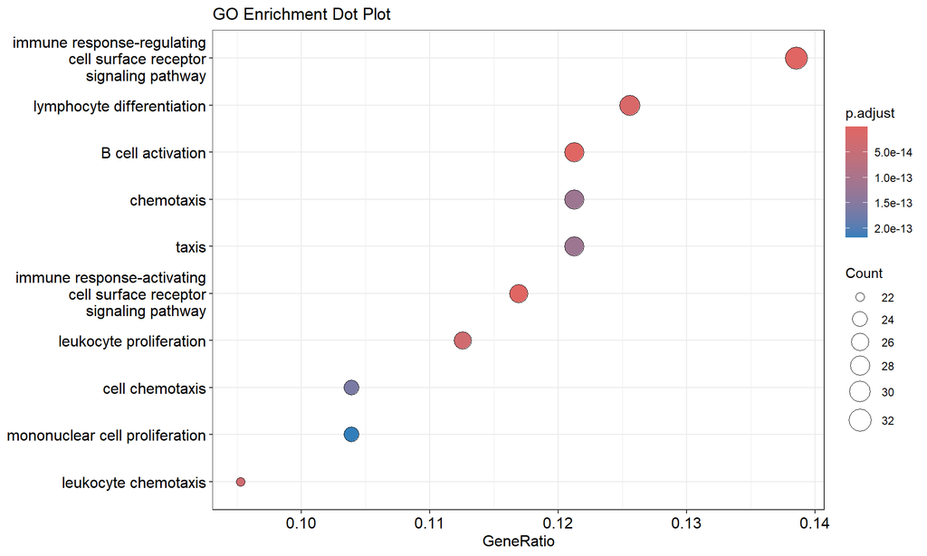

Gráficas significancia biológica SIN TRATAMIENTO

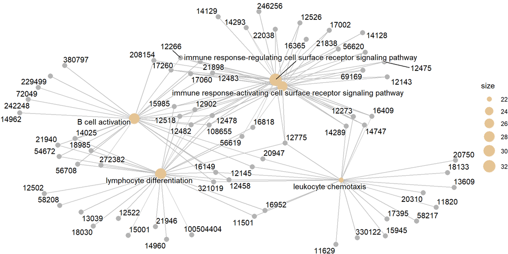

Red de genes expresados diferencialmente SIN TRATAMIENTO

En base a estos gráficos, la expresión génica diferencial parece que es importante en mayor medida para:

- Vía de señalización de receptores de superficie celular reguladores de la respuesta inmunitaria
- Diferenciación linfocitaria
- Activación de células B
- vía de señalización del receptor de superficie celular activador de la respuesta inmunitaria

*Significación biológica - Infectados y no Infectados para VANCOMICINA*

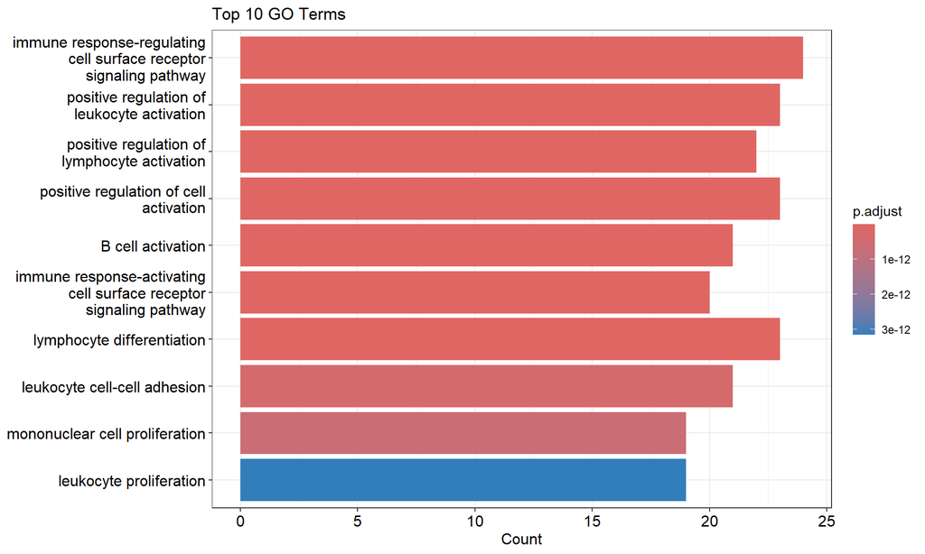

Gráficas significancia biológica VANCOMIZINA

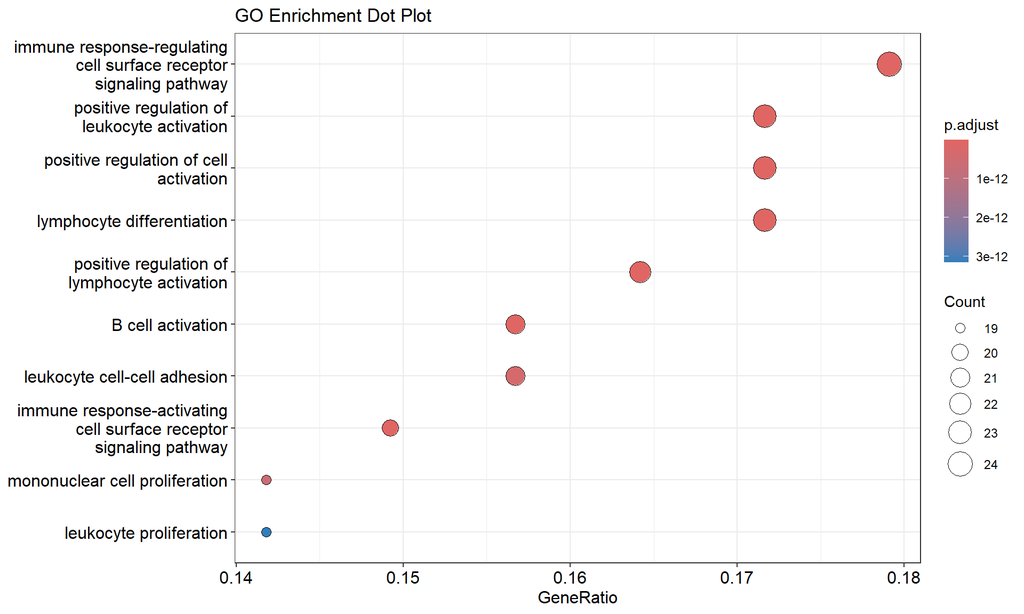

Gráficas significancia biológica VANCOMIZINA

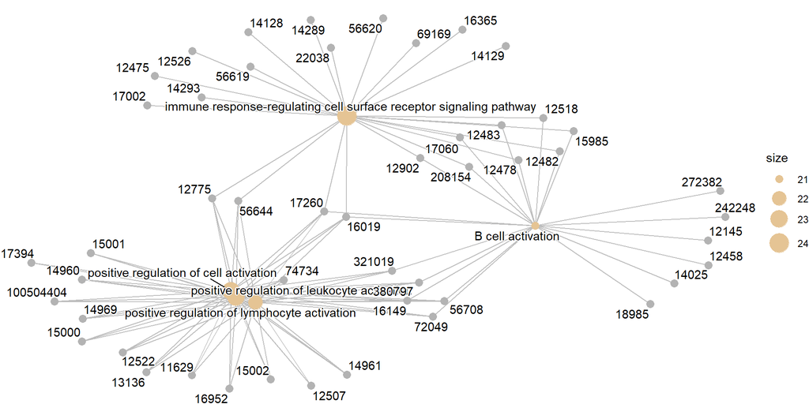

Red de genes expresados diferencialmente VANCOMIZINA

En base a estos gráficos, la expresión génica diferencial parece que es importante en mayor medida para:

- vía de señalización de receptores de superficie celular reguladores de la respuesta inmunitaria
- Regulación positiva de la activación leucocitaria
- Regulación positiva de la activación celular
- Diferenciación linfocitaria

*Significación biológica - Genes comunes en los tres estudios*

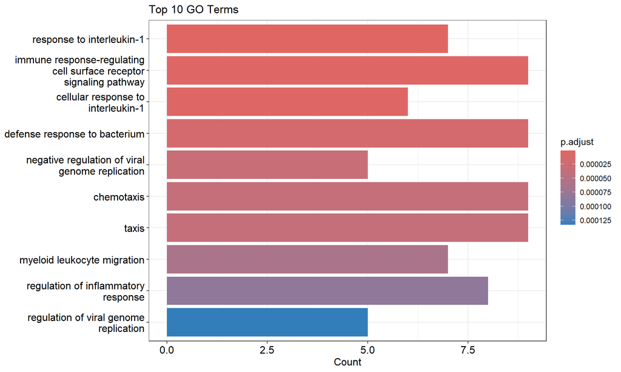

Gráficas significancia biológica GENES COMUNES

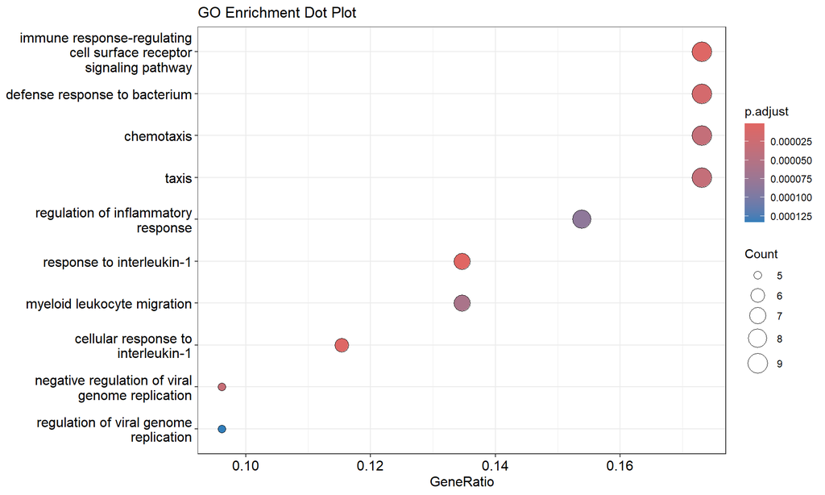

Gráficas significancia biológica GENES COMUNES

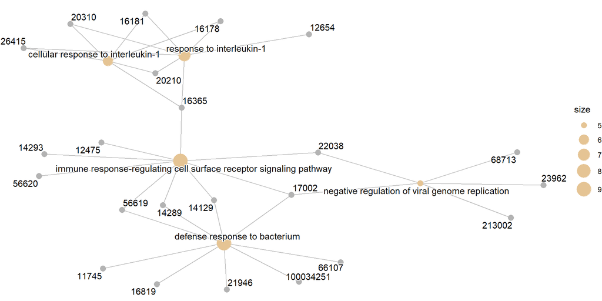

Red de genes expresados diferencialmente GENES COMUNES

En base a estos gráficos, la expresión génica diferencial parece que es importante en mayor medida para:

- Vía de señalización del receptor de superficie celular regulador de la respuesta inmunitaria
- Respuesta de defensa frente a la bacteria
- Quimiotaxis
- Regulación de la respuesta inflamatoria

# 5 Discusión

Tal y como se ha observado en la selección de genes expresados significativamentes, se ha podido observar que aquellos ratones que han sido tratados con Vancomizina, por si solos no tienen una expresión génica diferencial propia. Todos los genes que están expresados diferencialmente están compartido con el resto de grupos.

Por otra parte, aquellos que han sido tratados con linezolid tiene 62 genes expresados diferencialmente por si solos, por lo que se puede decir que este sería el tratamiento que más diferencias muestra.

De todas maneras, habría que realizar más estudios para determinar si el linezolid es el tratamiento más efectivo o no.

Al estudiar el análisis biólogico, se puede indentificar que, en todos los grupos, los *pathways* más representativos hacen referencia a algún tipo de respuesta inmunitaria pero, paara realizar un correcto análisis de significación biológico, lo óptimo sería contar con una persona que sepa analizar con más exactitud el significado biológico de los análisis e interpretar lo gráficos aquí mostrados.

# 6 Notas

Todo el código y los datos utilizados en la presente práctica se encuentran en el siguiente repositorio de Github: https://github.com/VegaUOC/Rodrigalvarez-Chamarro-MariadelaVega-PEC2

# 7 Referencias

El material usado para realizar la presente práctica es el proporcionado en la asignatura.

# 8 Apéndices

## 8.1 Apendice A. Tablas de genes mas significativos por contraste

### 8.1.1 Linezolid. Genes diferencialmente expresados Infectado y No Infectado

Genes diferencialmente expresados LINEZOLID

|  | logFC | AveExpr | t | P Value | adj P Val | B | PROBEID |
| --- | --- | --- | --- | --- | --- | --- | --- |
| 1421262_at | 6.157126 | 7.175233 | 16.810108 | 0.0000000 | 0.0000000 | 21.4731987 | 1421262_at |
| 1427747_a_at | 4.952167 | 10.693149 | 14.021250 | 0.0000000 | 0.0000000 | 18.0928961 | 1427747_a_at |
| 1419681_a_at | 4.798082 | 7.386037 | 13.269558 | 0.0000000 | 0.0000000 | 17.0705750 | 1419681_a_at |
| 1440865_at | 3.362591 | 11.173847 | 12.922501 | 0.0000000 | 0.0000000 | 16.5806509 | 1440865_at |
| 1422953_at | 2.840405 | 11.192299 | 12.311293 | 0.0000000 | 0.0000000 | 15.6888281 | 1422953_at |
| 1448562_at | 4.413814 | 7.599334 | 12.035169 | 0.0000000 | 0.0000000 | 15.2733289 | 1448562_at |
| 1436419_a_at | -2.207412 | 8.574273 | -11.725902 | 0.0000000 | 0.0000000 | 14.7982997 | 1436419_a_at |
| 1427102_at | 3.709836 | 10.546141 | 11.459946 | 0.0000000 | 0.0000000 | 14.3814229 | 1427102_at |
| 1417290_at | 3.954315 | 10.034197 | 11.298972 | 0.0000000 | 0.0000000 | 14.1252584 | 1417290_at |
| 1457728_at | -2.317387 | 6.607683 | -11.067667 | 0.0000000 | 0.0000001 | 13.7520011 | 1457728_at |
| 1449366_at | 3.486627 | 10.081210 | 11.015297 | 0.0000000 | 0.0000001 | 13.6666335 | 1449366_at |
| 1436530_at | 4.383425 | 9.985045 | 10.672959 | 0.0000000 | 0.0000001 | 13.1006512 | 1436530_at |
| 1418722_at | 4.142292 | 10.981607 | 10.517562 | 0.0000000 | 0.0000001 | 12.8391192 | 1418722_at |
| 1453568_at | -2.232933 | 7.823380 | -10.402443 | 0.0000000 | 0.0000001 | 12.6434851 | 1453568_at |
| 1448213_at | 2.479806 | 12.008671 | 10.382870 | 0.0000000 | 0.0000001 | 12.6100622 | 1448213_at |
| 1433966_x_at | 2.628378 | 6.040605 | 10.369701 | 0.0000000 | 0.0000001 | 12.5875475 | 1433966_x_at |
| 1424254_at | 3.819659 | 11.198672 | 10.347366 | 0.0000000 | 0.0000001 | 12.5493136 | 1424254_at |
| 1434484_at | 3.883814 | 9.333854 | 10.106201 | 0.0000000 | 0.0000001 | 12.1325432 | 1434484_at |
| 1426170_a_at | -2.350623 | 8.374877 | -9.616070 | 0.0000000 | 0.0000003 | 11.2629070 | 1426170_a_at |
| 1447806_s_at | -2.331375 | 7.824789 | -9.437494 | 0.0000000 | 0.0000003 | 10.9383620 | 1447806_s_at |
| 1420330_at | 2.888303 | 8.000858 | 9.436457 | 0.0000000 | 0.0000003 | 10.9364653 | 1420330_at |
| 1450826_a_at | 6.307702 | 9.343178 | 9.314701 | 0.0000000 | 0.0000003 | 10.7127721 | 1450826_a_at |
| 1424509_at | 3.612381 | 8.943432 | 9.282374 | 0.0000000 | 0.0000004 | 10.6530505 | 1424509_at |
| 1421366_at | 2.251795 | 6.277268 | 9.238549 | 0.0000000 | 0.0000004 | 10.5718669 | 1421366_at |
| 1437060_at | 3.879705 | 7.500708 | 9.222434 | 0.0000000 | 0.0000004 | 10.5419498 | 1437060_at |
| 1453181_x_at | 2.495037 | 6.889508 | 9.195191 | 0.0000000 | 0.0000004 | 10.4912971 | 1453181_x_at |
| 1456147_at | -2.064406 | 7.454899 | -9.096261 | 0.0000000 | 0.0000004 | 10.3065232 | 1456147_at |
| 1451537_at | 2.782989 | 7.910675 | 9.032555 | 0.0000000 | 0.0000004 | 10.1868435 | 1451537_at |
| 1425289_a_at | -2.097305 | 7.287404 | -8.924858 | 0.0000000 | 0.0000005 | 9.9832824 | 1425289_a_at |
| 1420591_at | 2.523120 | 6.159378 | 8.875661 | 0.0000000 | 0.0000005 | 9.8897721 | 1420591_at |

[output cut: 158 more lines]

### 8.1.2 Sin Tratamiento. Genes diferencialmente expresados Infectado y No Infectado

Genes diferencialmente expresados No Tratados

|  | logFC | AveExpr | t | P Value | adj P Val | B | PROBEID |
| --- | --- | --- | --- | --- | --- | --- | --- |
| 1421262_at | 7.202325 | 7.175233 | 19.663695 | 0.0000000 | 0.0000000 | 24.6409970 | 1421262_at |
| 1427747_a_at | 6.237323 | 10.693149 | 17.659957 | 0.0000000 | 0.0000000 | 22.5731026 | 1427747_a_at |
| 1422953_at | 3.851164 | 11.192299 | 16.692270 | 0.0000000 | 0.0000000 | 21.4869762 | 1422953_at |
| 1440865_at | 4.077956 | 11.173847 | 15.671662 | 0.0000000 | 0.0000000 | 20.2722418 | 1440865_at |
| 1418722_at | 6.033845 | 10.981607 | 15.320344 | 0.0000000 | 0.0000000 | 19.8364815 | 1418722_at |
| 1429387_at | -2.125765 | 6.421327 | -14.747242 | 0.0000000 | 0.0000000 | 19.1050911 | 1429387_at |
| 1419681_a_at | 5.264941 | 7.386037 | 14.560700 | 0.0000000 | 0.0000000 | 18.8613431 | 1419681_a_at |
| 1436419_a_at | -2.688060 | 8.574273 | -14.279135 | 0.0000000 | 0.0000000 | 18.4879723 | 1436419_a_at |
| 1448213_at | 3.362917 | 12.008671 | 14.080428 | 0.0000000 | 0.0000000 | 18.2204418 | 1448213_at |
| 1449366_at | 4.425505 | 10.081210 | 13.981494 | 0.0000000 | 0.0000000 | 18.0859737 | 1449366_at |
| 1433939_at | -2.001300 | 8.351123 | -13.979971 | 0.0000000 | 0.0000000 | 18.0838972 | 1433939_at |
| 1447806_s_at | -3.443607 | 7.824789 | -13.939851 | 0.0000000 | 0.0000000 | 18.0291189 | 1447806_s_at |
| 1422438_at | -2.173576 | 7.524873 | -13.554234 | 0.0000000 | 0.0000000 | 17.4953548 | 1422438_at |
| 1425518_at | -2.772911 | 6.687270 | -13.386359 | 0.0000000 | 0.0000000 | 17.2587990 | 1425518_at |
| 1453181_x_at | 3.626613 | 6.889508 | 13.365492 | 0.0000000 | 0.0000000 | 17.2292132 | 1453181_x_at |
| 1426775_s_at | 2.598049 | 7.408379 | 13.240355 | 0.0000000 | 0.0000000 | 17.0509503 | 1426775_s_at |
| 1417290_at | 4.580057 | 10.034197 | 13.086953 | 0.0000000 | 0.0000000 | 16.8304260 | 1417290_at |
| 1421366_at | 3.162701 | 6.277268 | 12.975765 | 0.0000000 | 0.0000000 | 16.6691941 | 1421366_at |
| 1434046_at | 5.300588 | 6.815033 | 12.875958 | 0.0000000 | 0.0000000 | 16.5234580 | 1434046_at |
| 1457728_at | -2.689488 | 6.607683 | -12.844798 | 0.0000000 | 0.0000000 | 16.4777613 | 1457728_at |
| 1448562_at | 4.670536 | 7.599334 | 12.735173 | 0.0000000 | 0.0000000 | 16.3162472 | 1448562_at |
| 1437060_at | 5.346060 | 7.500708 | 12.708102 | 0.0000000 | 0.0000000 | 16.2761813 | 1437060_at |
| 1419647_a_at | 3.599225 | 7.239192 | 12.619850 | 0.0000000 | 0.0000000 | 16.1450671 | 1419647_a_at |
| 1434484_at | 4.837274 | 9.333854 | 12.587232 | 0.0000000 | 0.0000000 | 16.0964116 | 1434484_at |
| 1419532_at | 4.902970 | 8.717034 | 12.551254 | 0.0000000 | 0.0000000 | 16.0426222 | 1419532_at |
| 1425289_a_at | -2.944158 | 7.287404 | -12.528552 | 0.0000000 | 0.0000000 | 16.0086147 | 1425289_a_at |
| 1440900_at | -2.418760 | 6.401088 | -12.490856 | 0.0000000 | 0.0000000 | 15.9520326 | 1440900_at |
| 1434848_at | 4.328388 | 5.824646 | 12.423607 | 0.0000000 | 0.0000000 | 15.8507375 | 1434848_at |
| 1420928_at | -2.426497 | 9.460342 | -12.228630 | 0.0000000 | 0.0000000 | 15.5544638 | 1420928_at |
| 1453568_at | -2.593626 | 7.823380 | -12.082780 | 0.0000000 | 0.0000000 | 15.3302911 | 1453568_at |

[output cut: 206 more lines]

### 8.1.3 Vancomicina. Genes diferencialmente expresados Infectado y No Infectado

Genes diferencialmente expresados. Vancomycina.

|  | logFC | AveExpr | t | P Value | adj P Val | B | PROBEID |
| --- | --- | --- | --- | --- | --- | --- | --- |
| 1421262_at | 6.636277 | 7.175233 | 18.118278 | 0.0000000 | 0.0000000 | 22.9434303 | 1421262_at |
| 1427747_a_at | 5.162365 | 10.693149 | 14.616391 | 0.0000000 | 0.0000000 | 18.8988440 | 1427747_a_at |
| 1419681_a_at | 5.211970 | 7.386037 | 14.414205 | 0.0000000 | 0.0000000 | 18.6369814 | 1419681_a_at |
| 1440865_at | 3.638019 | 11.173847 | 13.980975 | 0.0000000 | 0.0000000 | 18.0641039 | 1440865_at |
| 1418722_at | 5.213168 | 10.981607 | 13.236589 | 0.0000000 | 0.0000000 | 17.0406271 | 1418722_at |
| 1436419_a_at | -2.327081 | 8.574273 | -12.361589 | 0.0000000 | 0.0000000 | 15.7701242 | 1436419_a_at |
| 1419709_at | 5.233992 | 7.006511 | 12.265561 | 0.0000000 | 0.0000000 | 15.6260121 | 1419709_at |
| 1422953_at | 2.798300 | 11.192299 | 12.128797 | 0.0000000 | 0.0000000 | 15.4191158 | 1422953_at |
| 1447806_s_at | -2.954199 | 7.824789 | -11.958706 | 0.0000000 | 0.0000000 | 15.1590602 | 1447806_s_at |
| 1449366_at | 3.747495 | 10.081210 | 11.839458 | 0.0000000 | 0.0000000 | 14.9749026 | 1449366_at |
| 1425518_at | -2.428115 | 6.687270 | -11.721841 | 0.0000000 | 0.0000000 | 14.7917630 | 1425518_at |
| 1437060_at | 4.818901 | 7.500708 | 11.454993 | 0.0000000 | 0.0000000 | 14.3706465 | 1437060_at |
| 1448213_at | 2.728242 | 12.008671 | 11.423061 | 0.0000000 | 0.0000000 | 14.3197252 | 1448213_at |
| 1437356_at | -2.304486 | 7.957112 | -11.270315 | 0.0000000 | 0.0000000 | 14.0745652 | 1437356_at |
| 1434046_at | 4.636745 | 6.815033 | 11.263380 | 0.0000000 | 0.0000000 | 14.0633718 | 1434046_at |
| 1420928_at | -2.215863 | 9.460342 | -11.167113 | 0.0000000 | 0.0000000 | 13.9074293 | 1420928_at |
| 1436317_at | -2.950700 | 5.830050 | -10.963849 | 0.0000000 | 0.0000000 | 13.5746687 | 1436317_at |
| 1424509_at | 4.206020 | 8.943432 | 10.807787 | 0.0000000 | 0.0000000 | 13.3159255 | 1424509_at |
| 1425289_a_at | -2.531694 | 7.287404 | -10.773358 | 0.0000000 | 0.0000000 | 13.2584571 | 1425289_a_at |
| 1455340_at | -2.484658 | 5.958534 | -10.723095 | 0.0000000 | 0.0000000 | 13.1743090 | 1455340_at |
| 1460330_at | 3.165709 | 7.364740 | 10.719277 | 0.0000000 | 0.0000000 | 13.1679051 | 1460330_at |
| 1440900_at | -2.073249 | 6.401088 | -10.706583 | 0.0000000 | 0.0000000 | 13.1465998 | 1440900_at |
| 1419907_s_at | -2.753226 | 7.089150 | -10.581696 | 0.0000000 | 0.0000000 | 12.9359725 | 1419907_s_at |
| 1448293_at | -2.687156 | 6.568098 | -10.499043 | 0.0000000 | 0.0000001 | 12.7955445 | 1448293_at |
| 1434848_at | 3.644862 | 5.824646 | 10.461707 | 0.0000000 | 0.0000001 | 12.7318393 | 1434848_at |
| 1427102_at | 3.379195 | 10.546141 | 10.438570 | 0.0000000 | 0.0000001 | 12.6922773 | 1427102_at |
| 1448562_at | 3.771635 | 7.599334 | 10.284135 | 0.0000000 | 0.0000001 | 12.4265346 | 1448562_at |
| 1416630_at | -2.228066 | 7.077548 | -10.172121 | 0.0000000 | 0.0000001 | 12.2319546 | 1416630_at |
| 1419532_at | 3.957625 | 8.717034 | 10.131239 | 0.0000000 | 0.0000001 | 12.1605507 | 1419532_at |
| 1450357_a_at | -2.004817 | 7.286378 | -10.059938 | 0.0000000 | 0.0000001 | 12.0355210 | 1450357_a_at |

[output cut: 109 more lines]

## 8.2 Apendice B. Tablas de genes anotados

### 8.2.1 Genes significativos anotados para el estudio con Linezolid

| PROBEID | SYMBOL | GENENAME | ENSEMBL | ENTREZID |
| --- | --- | --- | --- | --- |
| 1415897_a_at | Mgst1 | microsomal glutathione S-transferase 1 | ENSMUSG00000008540 | 56615 |
| 1415994_at | Cyp2e1 | cytochrome P450, family 2, subfamily e, polypeptide 1 | ENSMUSG00000025479 | 13106 |
| 1416025_at | Fgg | fibrinogen gamma chain | ENSMUSG00000033860 | 99571 |
| 1416332_at | Cirbp | cold inducible RNA binding protein | ENSMUSG00000045193 | 12696 |
| 1416625_at | Serping1 | serine (or cysteine) peptidase inhibitor, clade G, member 1 | ENSMUSG00000023224 | 12258 |
| 1416649_at | Ambp | alpha 1 microglobulin/bikunin precursor | ENSMUSG00000028356 | 11699 |
| 1416676_at | Kng1 | kininogen 1 | ENSMUSG00000022875 | 16644 |
| 1416677_at | Apoh | apolipoprotein H | ENSMUSG00000000049 | 11818 |
| 1416729_at | Plg | plasminogen | ENSMUSG00000059481 | 18815 |
| 1417063_at | C1qb | complement component 1, q subcomponent, beta polypeptide | ENSMUSG00000036905 | 12260 |
| 1417074_at | Ceacam10 | CEA cell adhesion molecule 10 | ENSMUSG00000054169 | 26366 |
| 1417244_a_at | Irf7 | interferon regulatory factor 7 | ENSMUSG00000025498 | 54123 |
| 1417246_at | Pzp | PZP, alpha-2-macroglobulin like | ENSMUSG00000030359 | 11287 |
| 1417268_at | Cd14 | CD14 antigen | ENSMUSG00000051439 | 12475 |
| 1417290_at | Lrg1 | leucine-rich alpha-2-glycoprotein 1 | ENSMUSG00000037095 | 76905 |
| 1417300_at | Smpdl3b | sphingomyelin phosphodiesterase, acid-like 3B | ENSMUSG00000028885 | 100340 |
| 1417314_at | Cfb | complement factor B | ENSMUSG00000090231 | 14962 |
| 1417561_at | Apoc1 | apolipoprotein C-I | ENSMUSG00000040564 | 11812 |
| 1417640_at | Cd79b | CD79B antigen | ENSMUSG00000040592 | 15985 |
| 1417876_at | Fcgr1 | Fc receptor, IgG, high affinity I | ENSMUSG00000015947 | 14129 |
| 1417909_at | Serpinc1 | serine (or cysteine) peptidase inhibitor, clade C (antithrombin), member 1 | ENSMUSG00000026715 | 11905 |
| 1417950_a_at | Apoa2 | apolipoprotein A-II | ENSMUSG00000005681 | 11807 |
| 1418021_at | C4b | complement C4B (Chido blood group) | ENSMUSG00000073418 | 12268 |
| 1418162_at | Tlr4 | toll-like receptor 4 | ENSMUSG00000039005 | 21898 |
| 1418191_at | Usp18 | ubiquitin specific peptidase 18 | ENSMUSG00000030107 | 24110 |
| 1418204_s_at | Aif1 | allograft inflammatory factor 1 | ENSMUSG00000024397 | 11629 |
| 1418239_at | Apof | apolipoprotein F | ENSMUSG00000047631 | 103161 |
| 1418278_at | Apoc3 | apolipoprotein C-III | ENSMUSG00000032081 | 11814 |
| 1418282_x_at | Serpina1b | serine (or cysteine) preptidase inhibitor, clade A, member 1B | ENSMUSG00000071178 | 20701 |
| 1418580_at | Rtp4 | receptor transporter protein 4 | ENSMUSG00000033355 | 67775 |

[output cut: 158 more lines]

### 8.2.2 Genes significativos anotados para el estudio sin tratamiento

| PROBEID | SYMBOL | GENENAME | ENSEMBL | ENTREZID |
| --- | --- | --- | --- | --- |
| 1415897_a_at | Mgst1 | microsomal glutathione S-transferase 1 | ENSMUSG00000008540 | 56615 |
| 1415964_at | Scd1 | stearoyl-Coenzyme A desaturase 1 | ENSMUSG00000037071 | 20249 |
| 1416021_a_at | Fabp5 | fatty acid binding protein 5, epidermal | ENSMUSG00000027533 | 16592 |
| 1416107_at | Nsg2 | neuron specific gene family member 2 | ENSMUSG00000020297 | 18197 |
| 1416111_at | Cd83 | CD83 antigen | ENSMUSG00000015396 | 12522 |
| 1416125_at | Fkbp5 | FK506 binding protein 5 | ENSMUSG00000024222 | 14229 |
| 1416381_a_at | Prdx5 | peroxiredoxin 5 | ENSMUSG00000024953 | 54683 |
| 1416514_a_at | Fscn1 | fascin actin-bundling protein 1 | ENSMUSG00000029581 | 14086 |
| 1416871_at | Adam8 | a disintegrin and metallopeptidase domain 8 | ENSMUSG00000025473 | 11501 |
| 1416957_at | Pou2af1 | POU domain, class 2, associating factor 1 | ENSMUSG00000032053 | 18985 |
| 1417025_at | H2-Eb1 | histocompatibility 2, class II antigen E beta | ENSMUSG00000060586 | 14969 |
| 1417074_at | Ceacam10 | CEA cell adhesion molecule 10 | ENSMUSG00000054169 | 26366 |
| 1417190_at | Nampt | nicotinamide phosphoribosyltransferase | ENSMUSG00000020572 | 59027 |
| 1417268_at | Cd14 | CD14 antigen | ENSMUSG00000051439 | 12475 |
| 1417290_at | Lrg1 | leucine-rich alpha-2-glycoprotein 1 | ENSMUSG00000037095 | 76905 |
| 1417300_at | Smpdl3b | sphingomyelin phosphodiesterase, acid-like 3B | ENSMUSG00000028885 | 100340 |
| 1417314_at | Cfb | complement factor B | ENSMUSG00000090231 | 14962 |
| 1417460_at | Ifitm2 | interferon induced transmembrane protein 2 | ENSMUSG00000060591 | 80876 |
| 1417640_at | Cd79b | CD79B antigen | ENSMUSG00000040592 | 15985 |
| 1417688_at | Fam20c | FAM20C, golgi associated secretory pathway kinase | ENSMUSG00000025854 | 80752 |
| 1417741_at | Pygl | liver glycogen phosphorylase | ENSMUSG00000021069 | 110095 |
| 1417876_at | Fcgr1 | Fc receptor, IgG, high affinity I | ENSMUSG00000015947 | 14129 |
| 1417894_at | Adgrg3 | adhesion G protein-coupled receptor G3 | ENSMUSG00000060470 | 54672 |
| 1417933_at | Igfbp6 | insulin-like growth factor binding protein 6 | ENSMUSG00000023046 | 16012 |
| 1418162_at | Tlr4 | toll-like receptor 4 | ENSMUSG00000039005 | 21898 |
| 1418204_s_at | Aif1 | allograft inflammatory factor 1 | ENSMUSG00000024397 | 11629 |
| 1418353_at | Cd5 | CD5 antigen | ENSMUSG00000024669 | 12507 |
| 1418580_at | Rtp4 | receptor transporter protein 4 | ENSMUSG00000033355 | 67775 |
| 1418722_at | Ngp | neutrophilic granule protein | ENSMUSG00000032484 | 18054 |
| 1418762_at | Cd55 | CD55 molecule, decay accelerating factor for complement | ENSMUSG00000026399 | 13136 |

[output cut: 206 more lines]

### 8.2.3 Genes significativos anotados para el estudio con Vancomizina

| PROBEID | SYMBOL | GENENAME | ENSEMBL | ENTREZID |
| --- | --- | --- | --- | --- |
| 1415964_at | Scd1 | stearoyl-Coenzyme A desaturase 1 | ENSMUSG00000037071 | 20249 |
| 1416111_at | Cd83 | CD83 antigen | ENSMUSG00000015396 | 12522 |
| 1416630_at | Id3 | inhibitor of DNA binding 3 | ENSMUSG00000007872 | 15903 |
| 1416809_at | Cyp3a11 | cytochrome P450, family 3, subfamily a, polypeptide 11 | ENSMUSG00000056035 | 13112 |
| 1416957_at | Pou2af1 | POU domain, class 2, associating factor 1 | ENSMUSG00000032053 | 18985 |
| 1417025_at | H2-Eb1 | histocompatibility 2, class II antigen E beta | ENSMUSG00000060586 | 14969 |
| 1417074_at | Ceacam10 | CEA cell adhesion molecule 10 | ENSMUSG00000054169 | 26366 |
| 1417268_at | Cd14 | CD14 antigen | ENSMUSG00000051439 | 12475 |
| 1417290_at | Lrg1 | leucine-rich alpha-2-glycoprotein 1 | ENSMUSG00000037095 | 76905 |
| 1417640_at | Cd79b | CD79B antigen | ENSMUSG00000040592 | 15985 |
| 1417688_at | Fam20c | FAM20C, golgi associated secretory pathway kinase | ENSMUSG00000025854 | 80752 |
| 1417876_at | Fcgr1 | Fc receptor, IgG, high affinity I | ENSMUSG00000015947 | 14129 |
| 1417933_at | Igfbp6 | insulin-like growth factor binding protein 6 | ENSMUSG00000023046 | 16012 |
| 1418204_s_at | Aif1 | allograft inflammatory factor 1 | ENSMUSG00000024397 | 11629 |
| 1418353_at | Cd5 | CD5 antigen | ENSMUSG00000024669 | 12507 |
| 1418722_at | Ngp | neutrophilic granule protein | ENSMUSG00000032484 | 18054 |
| 1418762_at | Cd55 | CD55 molecule, decay accelerating factor for complement | ENSMUSG00000026399 | 13136 |
| 1418770_at | Cd2 | CD2 antigen | ENSMUSG00000027863 | 12481 |
| 1418830_at | Cd79a | CD79A antigen (immunoglobulin-associated alpha) | ENSMUSG00000003379 | 12518 |
| 1419178_at | Cd3g | CD3 antigen, gamma polypeptide | ENSMUSG00000002033 | 12502 |
| 1419297_at | H2-Oa | histocompatibility 2, O region alpha locus | ENSMUSG00000024334 | 15001 |
| 1419307_at | Tnfrsf13c | tumor necrosis factor receptor superfamily, member 13c | ENSMUSG00000068105 | 72049 |
| 1419406_a_at | Bcl11a | BCL11 transcription factor A | ENSMUSG00000000861 | 14025 |
| 1419532_at | Il1r2 | interleukin 1 receptor, type II | ENSMUSG00000026073 | 16178 |
| 1419599_s_at | Ms4a6d | membrane-spanning 4-domains, subfamily A, member 6D | ENSMUSG00000024679 | 68774 |
| 1419647_a_at | Ier3 | immediate early response 3 | ENSMUSG00000003541 | 15937 |
| 1419681_a_at | Prok2 | prokineticin 2 | ENSMUSG00000030069 | 50501 |
| 1419691_at | Camp | cathelicidin antimicrobial peptide | ENSMUSG00000038357 | 12796 |
| 1419709_at | Stfa3 | stefin A3 | ENSMUSG00000054905 | 20863 |
| 1419744_at | H2-DMb2 | histocompatibility 2, class II, locus Mb2 | ENSMUSG00000037548 | 15000 |

[output cut: 109 more lines]

### 8.2.4 Genes significativos anotados comunes a los tres estudios

| PROBEID | SYMBOL | GENENAME | ENSEMBL | ENTREZID |
| --- | --- | --- | --- | --- |
| 1436530_at | Wfdc17 | WAP four-disulfide core domain 17 | ENSMUSG00000069792 | 100034251 |
| 1418204_s_at | Aif1 | allograft inflammatory factor 1 | ENSMUSG00000024397 | 11629 |
| 1460330_at | Anxa3 | annexin A3 | ENSMUSG00000029484 | 11745 |
| 1417268_at | Cd14 | CD14 antigen | ENSMUSG00000051439 | 12475 |
| 1451537_at | Chi3l1 | chitinase 3 like 1 | ENSMUSG00000064246 | 12654 |
| 1419764_at | Chil3 | chitinase-like 3 | ENSMUSG00000040809 | 12655 |
| 1427256_at | Vcan | versican | ENSMUSG00000021614 | 13003 |
| 1417876_at | Fcgr1 | Fc receptor, IgG, high affinity I | ENSMUSG00000015947 | 14129 |
| 1422953_at | Fpr2 | formyl peptide receptor 2 | ENSMUSG00000052270 | 14289 |
| 1450808_at | Fpr1 | formyl peptide receptor 1 | ENSMUSG00000045551 | 14293 |
| 1448485_at | Ggt1 | gamma-glutamyltransferase 1 | ENSMUSG00000006345 | 14598 |
| 1434848_at | Gpr27 | G protein-coupled receptor 27 | ENSMUSG00000072875 | 14761 |
| 1419647_a_at | Ier3 | immediate early response 3 | ENSMUSG00000003541 | 15937 |
| 1419532_at | Il1r2 | interleukin 1 receptor, type II | ENSMUSG00000026073 | 16178 |
| 1451798_at | Il1rn | interleukin 1 receptor antagonist | ENSMUSG00000026981 | 16181 |
| 1427381_at | Acod1 | aconitate decarboxylase 1 | ENSMUSG00000022126 | 16365 |
| 1427747_a_at | Lcn2 | lipocalin 2 | ENSMUSG00000026822 | 16819 |
| 1421262_at | Lipg | lipase, endothelial | ENSMUSG00000053846 | 16891 |
| 1448213_at | Anxa1 | annexin A1 | ENSMUSG00000024659 | 16952 |
| 1450009_at | Ltf | lactotransferrin | ENSMUSG00000032496 | 17002 |
| 1449366_at | Mmp8 | matrix metallopeptidase 8 | ENSMUSG00000005800 | 17394 |
| 1448291_at | Mmp9 | matrix metallopeptidase 9 | ENSMUSG00000017737 | 17395 |
| 1418722_at | Ngp | neutrophilic granule protein | ENSMUSG00000032484 | 18054 |
| 1450826_a_at | Saa3 | serum amyloid A 3 | ENSMUSG00000040026 | 20210 |
| 1449984_at | Cxcl2 | C-X-C motif chemokine ligand 2 | ENSMUSG00000058427 | 20310 |
| 1427102_at | Slfn4 | schlafen 4 | ENSMUSG00000000204 | 20558 |
| 1449254_at | Spp1 | secreted phosphoprotein 1 | ENSMUSG00000029304 | 20750 |
| 1419709_at | Stfa3 | stefin A3 | ENSMUSG00000054905 | 20863 |
| 1440865_at | Ifitm6 | interferon induced transmembrane protein 6 | ENSMUSG00000059108 | 213002 |
| 1449184_at | Pglyrp1 | peptidoglycan recognition protein 1 | ENSMUSG00000030413 | 21946 |
| 1453181_x_at | Plscr1 | phospholipid scramblase 1 | ENSMUSG00000032369 | 22038 |
| 1448562_at | Upp1 | uridine phosphorylase 1 | ENSMUSG00000020407 | 22271 |
| 1421366_at | Clec5a | C-type lectin domain family 5, member a | ENSMUSG00000029915 | 23845 |
| 1453196_a_at | Oasl2 | 2’-5’ oligoadenylate synthetase-like 2 | ENSMUSG00000029561 | 23962 |
| 1426774_at | Parp12 | poly (ADP-ribose) polymerase family, member 12 | ENSMUSG00000038507 | 243771 |
| 1417074_at | Ceacam10 | CEA cell adhesion molecule 10 | ENSMUSG00000054169 | 26366 |
| 1448871_at | Mapk13 | mitogen-activated protein kinase 13 | ENSMUSG00000004864 | 26415 |
| 1433966_x_at | Asns | asparagine synthetase | ENSMUSG00000029752 | 27053 |
| 1437060_at | Olfm4 | olfactomedin 4 | ENSMUSG00000022026 | 380924 |
| 1434046_at | AA467197 | expressed sequence AA467197 | ENSMUSG00000033213 | 433470 |
| 1419681_a_at | Prok2 | prokineticin 2 | ENSMUSG00000030069 | 50501 |
| 1456388_at | Atp11a | ATPase, class VI, type 11A | ENSMUSG00000031441 | 50770 |
| 1420330_at | Clec4e | C-type lectin domain family 4, member e | ENSMUSG00000030142 | 56619 |
| 1425951_a_at | Clec4n | C-type lectin domain family 4, member n | ENSMUSG00000023349 | 56620 |
| 1434484_at | Wfdc21 | WAP four-disulfide core domain 21 | ENSMUSG00000051748 | 66107 |
| 1452732_at | Asprv1 | aspartic peptidase, retroviral-like 1 | ENSMUSG00000033508 | 67855 |
| 1424254_at | Ifitm1 | interferon induced transmembrane protein 1 | ENSMUSG00000025491 | 68713 |
| 1419599_s_at | Ms4a6d | membrane-spanning 4-domains, subfamily A, member 6D | ENSMUSG00000024679 | 68774 |
| 1424509_at | Cd177 | CD177 antigen | ENSMUSG00000052212 | 68891 |
| 1417290_at | Lrg1 | leucine-rich alpha-2-glycoprotein 1 | ENSMUSG00000037095 | 76905 |
| 1434758_at | Crispld2 | cysteine-rich secretory protein LCCL domain containing 2 | ENSMUSG00000031825 | 78892 |
| 1420591_at | Gpr84 | G protein-coupled receptor 84 | ENSMUSG00000063234 | 80910 |

## 8.3 Apéndice C. Código

```r
knitr::opts_chunk$set(echo = FALSE)
knitr::opts_chunk$set(warning = FALSE, message = FALSE)
# Install packages
# Load packages

library(knitr)

# Librería Bioconductor
if (!require("BiocManager", quietly = TRUE))
  install.packages("BiocManager")

# Lectura de CELFiles
if (!require(oligo)){
    BiocManager::install(oligo)
}
library(oligo)

# Paquete de calidad
if (!require(arrayQualityMetrics)){
  BiocManager::install(arrayQualityMetrics)
}
library(arrayQualityMetrics)

# Paquete de anotación
if (!require(mouse4302.db)){
  BiocManager::install("mouse4302.db")
}
library("mouse4302.db")

# Filtrado y anotación de genes
if (!require(genefilter)){
    BiocManager::install(genefilter)
}
library(genefilter)

if (!require("limma")){
  BiocManager::install("limma")
}
library("limma")

if (!require(annotate)){
  BiocManager::install(annotate)
}
library(annotate)

if (!require(biomaRt)){
  BiocManager::install(biomaRt)
}
library(biomaRt)

BiocManager::install(c("clusterProfiler", "org.Mm.eg.db"))
library("clusterProfiler")
library(org.Mm.eg.db)

# Preparación de los datos. Filtrado de los datos

# Función para realizar el filtrado de los datos
filter_microarray <- function(allTargets, seed = 123) {
  # Configurar la semilla aleatoria
  print(seed)
  set.seed(seed)

  # Filtrar las filas donde 'time' no sea 'hour 2'
  filtered <- subset(allTargets, time != "hour 2")

  # Dividir el dataset por grupos únicos de 'infection' + 'agent'
  filtered$group <- interaction(filtered$infection, filtered$agent)

  # Seleccionar 4 muestras al azar de cada grupo
  selected <- do.call(rbind, lapply(split(filtered, filtered$group),
                                    function(group_data) {
    if (nrow(group_data) > 4) {
      group_data[sample(1:nrow(group_data), 4), ]
    } else {
      group_data
    }
  }))

  # Obtener los índices originales como nombres de las filas seleccionadas
  original_indices <- match(selected$sample, allTargets$sample)

  # Modificar los rownames usando 'sample' y los índices originales
  rownames(selected) <- paste0(selected$sample, ".", original_indices)

  # Eliminar la columna 'group' y devolver el resultado
  selected$group <- NULL
  return(selected)
}

# Simular el dataset basado en la descripción proporcionada
sample = c("GSM944831", "GSM944838", "GSM944845", "GSM944852", "GSM944859",
           "GSM944833", "GSM944840", "GSM944847", "GSM944854", "GSM944861",
           "GSM944834", "GSM944841", "GSM944848", "GSM944855", "GSM944862",
           "GSM944832", "GSM944839", "GSM944846", "GSM944853", "GSM944860",
           "GSM944835", "GSM944842", "GSM944849", "GSM944856", "GSM944863",
           "GSM944836", "GSM944843", "GSM944850", "GSM944857", "GSM944864",
           "GSM944837", "GSM944844", "GSM944851", "GSM944858", "GSM944865")

allTargets <- data.frame(
  sample = sample,
  infection = c(rep("uninfected", 15), rep("S. aureus USA300", 20)),
  time = c(rep("hour 0", 15), rep("hour 2", 5), rep("hour 24", 15)),
  agent = c(rep("untreated", 5), rep("linezolid", 5), rep("vancomycin", 5),
            rep("untreated", 5), rep("untreated", 5), rep("linezolid", 5),
            rep("vancomycin", 5)),
  filename = paste0(sample, ".CEL"),
  color = c(rep("lightblue", 5), rep("pink", 5), rep("lightgreen", 5),
            rep("grey", 5), rep("blue", 5), rep("red", 5), rep("green", 5))
)

# Aplicar la función (cambiar 123 por vuestro ID de la UOC u otro número que
# podáis escribir en el documento)
result <- filter_microarray(allTargets, seed=25178976)

result$grupo <- c(rep("INF.LIN",4),rep("NOINF.LIN",4),rep("INF.NOTTREAT",4),
                  rep("NOINF.NOTTREAT",4),rep("INF.VAN",4),rep("NOINF.VAN",4))

# Se crea el objeto AnnotatedDataFrame
targets <- AnnotatedDataFrame(result)

# Cargar todos los ficheros uno a uno con extensión CEL
celFiles <- result$filename
rawData <- read.celfiles(file.path(params$data_folder,celFiles),phenoData=targets)

#Diagrama de cajas

sampleNames <- as.character(result$grupo)
sampleColor <- as.character(result$color)

boxplot(rawData, which="all",las=2, main="Distribución intensidad datos en crudo",
        cex.axis=0.6, col=sampleColor, names=sampleNames)
legend("topright", legend = c("US3000 - linezolid", "No infectado - linezolid",
                              "US3000 - sin tratamiento","No infectado - Sin Tratamiento",
                              "US3000 - vancomycin","No infectado - vancomycin"),
       fill = c("red", "pink", "blue","lightblue","green","lightgreen"), title = "Grupos")

# Agrupación por clusters
clust.euclid.average <- hclust(dist(t(exprs(rawData))),method="average")
plot(clust.euclid.average, labels<-sampleNames,
     main="Clustering jerarquizado datos en crudo",cex=0.7,hang=-1 )

# Función para realizar una representacion de PCA

plotPCA <- function ( X, labels=NULL, colors=NULL, dataDesc="", scale=FALSE,
                      formapunts=NULL, myCex=0.8,...)
{
  pcX<-prcomp(t(X), scale=scale) # o prcomp(t(X))
  loads<- round(pcX$sdev^2/sum(pcX$sdev^2)*100,1)
  xlab<-c(paste("PC1",loads[1],"%"))
  ylab<-c(paste("PC2",loads[2],"%"))
  if (is.null(colors)) colors=1
  plot(pcX$x[,1:2],xlab=xlab,ylab=ylab, col=colors, pch=formapunts,
       xlim=c(min(pcX$x[,1])-100000, max(pcX$x[,1])+100000),ylim=c(min(pcX$x[,2])-100000,
                                                                   max(pcX$x[,2])+100000))
  text(pcX$x[,1],pcX$x[,2], labels, pos=3, cex=myCex)
  title(paste("Plot of first 2 PCs for expressions in", dataDesc, sep=" "), cex=0.8)
  legend("bottomright", legend = c("US3000 - linezolid", "No infectado - linezolid",
                                "US3000 - sin tratamiento",
                                "No infectado - Sin Tratamiento",
                                "US3000 - vancomycin","No infectado - vancomycin"),
         col = c("red", "pink", "blue","lightblue","green","lightgreen"),
         pch = c(15,22,16,21,17,24), title = "Grupos")
}

# Representación gráfica del Análisis de componentes principales (PCA)
plotPCA(exprs(rawData), labels=sampleNames, dataDesc="raw data", colors=sampleColor,
        formapunts=c(rep(15,4),rep(22,4),rep(16,4),rep(21,4),rep(17,4),rep(24,4)),
        myCex=0.5)
```

```r
## Control de calidad con el paquete `arrayQualityMetrics`
# Avoid re-running it each time  the script is executed.
rerun <- FALSE
if(rerun){
  arrayQualityMetrics(rawData,  reporttitle="Anexo I. Calidad de los datos", force=TRUE)
}

# Construcción del Expression set
eset<-rma(rawData)
write.exprs(eset, file.path(params$results_folder, "NormData.txt"))

# Filtrado de los datos. Variabilidad de más del 90%
annotation(eset)<-"mouse4302.db"
eset_filtered <- nsFilter(eset, var.func=IQR,
                          var.cutoff=0.9, var.filter=TRUE, require.entrez=FALSE,
                          filterByQuantile=TRUE)
#Número de genes borrados
print(eset_filtered)

#Número de genes incluidos en el estudio
print(eset_filtered$eset)
dim(eset_filtered$eset)

# Matriz de datos filtrados

filteredEset <- eset_filtered$eset
filteredData <- exprs(filteredEset)
colnames(filteredData) <- rownames(pData(eset_filtered$eset))

# Creación de la matriz de diseño

lev <- factor(result$grupo, levels = unique(result$grupo))
design <-model.matrix(~0+lev,pData(filteredEset))
colnames(design) <- levels(lev)
rownames(design) <- sampleNames

# Visualización de la matriz de diseño

knitr::kable(design,
             col.names = gsub("[.]", " ", colnames(design)),
             booktabs = TRUE,
             caption = 'Matriz de diseño')

# Creación de la matriz de contraste
mCont <- makeContrasts(LIN_INF_NOINF = INF.LIN - NOINF.LIN,
                       NOTTREAT_INF_NOINF = INF.NOTTREAT - NOINF.NOTTREAT,
                       VAN_INF_NOINF = INF.VAN - NOINF.VAN,
                       levels = design)

# Visualización de la matriz de contraste
knitr::kable(mCont,
             col.names = gsub("[.]", " ", colnames(mCont)),
             booktabs = TRUE,
             caption = 'Matriz de contraste')

 # Construcción del modelo lineal

fit <- lmFit(filteredEset,design)
fit.main <- contrasts.fit(fit,mCont)
fit.main <- eBayes(fit.main)

# Función para generar los mapas de calor
plotHeatmap <- function ( X, title="")
{
  selectedData <- filteredData[X,]

  #HEATMAP PLOT
  my_palette <- colorRampPalette(c("yellow", "red"))(n = 299)
  library(gplots)
  heatmap.2(selectedData,
            Rowv=TRUE,
            Colv=TRUE,
            main=title,
            scale="row",
            col=my_palette,
            sepcolor="white",
            sepwidth=c(0.05,0.05),
            cexRow=0.5,
            cexCol=0.9,
            key=TRUE,
            keysize=1.5,
            density.info="histogram",
            ColSideColors=sampleColor,
            tracecol=NULL,
            srtCol=30)

}

# Tratamiento Linezolid - diferencia entre Infectados y no infectados
topTabLIN <-  topTable (fit.main, number=nrow(fit.main), coef="LIN_INF_NOINF",
                      adjust="fdr", lfc=2, p.value=0.05)

# Sin tratamiento - diferencia entre Infectados y no infectados
topTabNOTTREAT <-  topTable (fit.main, number=nrow(fit.main), coef="NOTTREAT_INF_NOINF",
                        adjust="fdr", lfc=2, p.value=0.05)

# Vancomycin - diferencia entre Infectados y no infectados
topTabVAN <-  topTable (fit.main, number=nrow(fit.main), coef="VAN_INF_NOINF",
                             adjust="fdr", lfc=2, p.value=0.05)

# Linezolid. Visualización de la tabla Infectados vs No Infectados
knitr::kable(head(topTabLIN),
             col.names = gsub("[.]", " ", colnames(topTabLIN)),
             booktabs = TRUE,
             caption = 'Genes diferencialmente expresados LINEZOLID')

# Tabla de los genes diferencialmente expresados
#Linezolid. Infectados vs No Infectados
selectedRows <- rownames(filteredData) %in% rownames(topTabLIN)
title <- paste("HeatMap LINEZOLID", "Infectados vs No Infectados FC>=2", sep="\n")
plotHeatmap(selectedRows,title)

# NoTratados. Visualización de la tabla Infectados vs No Infectados
knitr::kable(head(topTabNOTTREAT),
             col.names = gsub("[.]", " ", colnames(topTabNOTTREAT)),
             booktabs = TRUE,
             caption = 'Genes diferencialmente expresados No Tratados')

# Tabla de los genes diferencialmente expresados
#No tratados. Infectados vs No Infectados
selectedRows <- rownames(filteredData) %in% rownames(topTabNOTTREAT)
title <- paste("HeatMap Sin Tratamiento", "Infectados vs No Infectados FC>=2", sep="\n")
plotHeatmap(selectedRows,title)

# NoTratados. Visualización de la tabla Infectados vs No Infectados
knitr::kable(head(topTabVAN),
             col.names = gsub("[.]", " ", colnames(topTabVAN)),
             booktabs = TRUE,
             caption = 'Genes diferencialmente expresados. Vancomycina.')

# Tabla de los genes diferencialmente expresados
#Vancomycin. Infectados vs No Infectados
selectedRows <- rownames(filteredData) %in% rownames(topTabVAN)
title <- paste("HeatMap VANCOMYCIN", "Infectados vs No Infectados FC>=2", sep="\n")
plotHeatmap(selectedRows,title)

# Detección de genes expresados diferencialmente
rtdo_contrates <- decideTests(fit.main, method = "separate", adjust.method = "fdr",
                       p.value = 0.05, lfc = 2)

# LINZENOLID
genes_up_LIN <- rownames(filteredEset)[rtdo_contrates[, "LIN_INF_NOINF"] == 1]
genes_notSig_LIN <- rownames(filteredEset)[rtdo_contrates[, "LIN_INF_NOINF"] == 0]
genes_down_LIN <- rownames(filteredEset)[rtdo_contrates[, "LIN_INF_NOINF"] == -1]
up_LIN <- length(genes_up_LIN)
notSign_LIN <- length(genes_notSig_LIN)
down_LIN <- length(genes_down_LIN)

# SIN TRATAMIENTO
genes_up_NT <- rownames(filteredEset)[rtdo_contrates[, "NOTTREAT_INF_NOINF"] == 1]
genes_notSig_NT <- rownames(filteredEset)[rtdo_contrates[, "NOTTREAT_INF_NOINF"] == 0]
genes_down_NT <- rownames(filteredEset)[rtdo_contrates[, "NOTTREAT_INF_NOINF"] == -1]
up_NT <- length(genes_up_NT)
notSign_NT <- length(genes_notSig_NT)
down_NT <- length(genes_down_NT)

# VANCOMICINA
genes_up_VAN <- rownames(filteredEset)[rtdo_contrates[, "VAN_INF_NOINF"] == 1]
genes_notSig_VAN <- rownames(filteredEset)[rtdo_contrates[, "VAN_INF_NOINF"] == 0]
genes_down_VAN <- rownames(filteredEset)[rtdo_contrates[, "VAN_INF_NOINF"] == -1]
up_VAN <- length(genes_up_VAN)
notSign_VAN <- length(genes_notSig_VAN)
down_VAN <- length(genes_down_VAN)
```

```r
common_UP_LIN_NT <- intersect(genes_up_LIN, genes_up_NT)
common_UP_LIN_VAN <- intersect(genes_up_LIN, genes_up_VAN)
common_UP_NT_VAN <- intersect(genes_up_NT, genes_up_VAN)
common_UP_LIN_NT_VAN <- intersect(common_UP_LIN_NT,common_UP_LIN_VAN )
# Genes comunes expresados diferencialmente a los tres estudios
vennTable <- vennCounts(rtdo_contrates,include="up")

knitr::kable(vennTable[1:dim(vennTable)[1],1:dim(vennTable)[2]],
             col.names = gsub("[.]", " ", c("Linezolid","Sin Tratamiento",
                                            "Vancomizina","N Comunes")),
             booktabs = TRUE,
             caption = 'Genes comunes en los diferentes estudios')

# Diagrama de Venn Genes altamente diferenciados entre grupos

vennDiagram(rtdo_contrates, include = "up")

# Estudio de contraste Linezolid
topTabLIN$PROBEID <- rownames(topTabLIN)
myProbes_LIN <- topTabLIN$PROBEID
# Se realiza la anotación de los genes
geneAnots_LIN <- AnnotationDbi::select(mouse4302.db, keys=myProbes_LIN,
                    columns = c("SYMBOL","GENENAME","ENSEMBL","ENTREZID"))

# Se mezclan ambas tablas por PROBEID, para ordenarlas se mantiene el valor de B
annotatedTopTab_LIN <- merge(x=geneAnots_LIN, y=topTabLIN, by.x="PROBEID", by.y="PROBEID")
# Se ordenan las claves en orden descendente pro la columna B
sortAnnotatedTopTabLIn <- annotatedTopTab_LIN[order(-topTabLIN$B),
                                 c("PROBEID","SYMBOL","GENENAME","ENSEMBL","ENTREZID",
                                   "B")]
sortAnnotatedTopTabLIn <- sortAnnotatedTopTabLIn[!is.na(sortAnnotatedTopTabLIn$SYMBOL),]
dim(sortAnnotatedTopTabLIn)

# Estudio de contraste Sin tratamiento
topTabNOTTREAT$PROBEID <- rownames(topTabNOTTREAT)
myProbes_NOTTREAT <- topTabNOTTREAT$PROBEID
# Se realiza la anotación de los genes
geneAnots_NOTTREAT <- AnnotationDbi::select(mouse4302.db, keys=myProbes_NOTTREAT,
                        columns = c("SYMBOL","GENENAME","ENSEMBL","ENTREZID"))

# Se mezclan ambas tablas por PROBEID, para ordenarlas se mantiene el valor de B
annotatedTopTab_NOTTREAT <- merge(x=geneAnots_NOTTREAT, y=topTabNOTTREAT,
                                  by.x="PROBEID", by.y="PROBEID")
# Se ordenan las claves en orden descendente pro la columna B
sortAnnotatedTopTabNOTTREAT <- annotatedTopTab_NOTTREAT[order(-topTabNOTTREAT$B),
                                                        c("PROBEID","SYMBOL","GENENAME","ENSEMBL",
                                                          "ENTREZID",
                                                "B")]
sortAnnotatedTopTabNOTTREAT <- sortAnnotatedTopTabNOTTREAT[!is.na(sortAnnotatedTopTabNOTTREAT$SYMBOL),]
dim(sortAnnotatedTopTabNOTTREAT)

# Estudio de contraste Vancomicina
topTabVAN$PROBEID <- rownames(topTabVAN)
myProbes_VAN <- topTabVAN$PROBEID
# Se realiza la anotación de los genes
geneAnots_VAN <- AnnotationDbi::select(mouse4302.db, keys=myProbes_VAN,
                             columns = c("SYMBOL","GENENAME","ENSEMBL","ENTREZID"))

# Se mezclan ambas tablas por PROBEID, para ordenarlas se mantiene el valor de B
annotatedTopTab_VAN <- merge(x=geneAnots_VAN, y=topTabVAN, by.x="PROBEID", by.y="PROBEID")
# Se ordenan las claves en orden descendente pro la columna B
sortAnnotatedTopTabVAN <- annotatedTopTab_VAN[order(-topTabVAN$B),
                                              c("PROBEID","SYMBOL","GENENAME",
                                                "ENSEMBL","ENTREZID","B")]
sortAnnotatedTopTabVAN <- sortAnnotatedTopTabVAN[!is.na(sortAnnotatedTopTabVAN$SYMBOL),]
dim(sortAnnotatedTopTabVAN)

# Se realiza la anotación de los genes comunes a los tres estudios
geneAnots_common <- AnnotationDbi::select(mouse4302.db, keys=common_UP_LIN_NT_VAN,
                                       columns = c("SYMBOL","GENENAME","ENSEMBL","ENTREZID"))


# Genes diferencialmente expresados y anotados para el contraste de Linezolid
knitr::kable(head(sortAnnotatedTopTabLIn[,c("PROBEID","SYMBOL","GENENAME","ENSEMBL",
                                             "ENTREZID")],10),
             col.names = gsub("[.]", " ", c("PROBEID","SYMBOL","GENENAME","ENSEMBL",
                                             "ENTREZID")),
             booktabs = TRUE,
             caption = 'Principales genes diferencialmente expresados. Linezolid')

# Genes diferencialmente expresados y anotados para el contraste Sin Tratamiento
knitr::kable(head(sortAnnotatedTopTabNOTTREAT[,c("PROBEID","SYMBOL","GENENAME","ENSEMBL",
                                                 "ENTREZID")],10),
             col.names = gsub("[.]", " ", c("PROBEID","SYMBOL","GENENAME","ENSEMBL",
                                             "ENTREZID")),
             booktabs = TRUE,
             caption = 'Principales genes diferencialmente expresados. Sin tratamiento')

# Genes diferencialmente expresados y anotados para el contraste de Vancomicina
knitr::kable(head(sortAnnotatedTopTabVAN[,c("PROBEID","SYMBOL","GENENAME","ENSEMBL",
                                            "ENTREZID")],10),
             col.names = gsub("[.]", " ", c("PROBEID","SYMBOL","GENENAME","ENSEMBL",
                                             "ENTREZID")),
             booktabs = TRUE,
             caption = 'Principales genes diferencialmente expresados. Vancomizina')

# Genes diferencialmente expresados y anotados para el contraste de Vancomicina
knitr::kable(head(geneAnots_common[,c("PROBEID","SYMBOL","GENENAME","ENSEMBL",
                                            "ENTREZID")],10),
             col.names = gsub("[.]", " ", c("PROBEID","SYMBOL","GENENAME","ENSEMBL",
                                             "ENTREZID")),
             booktabs = TRUE,
             caption = 'Principales genes diferencialmente expresados. Comunes')

genes_ENTREZ_LIN <- sortAnnotatedTopTabLIn$ENTREZID

ego_LIN <- enrichGO(
  gene = genes_ENTREZ_LIN,
  OrgDb = org.Mm.eg.db,
  keyType = "ENTREZID",
  ont = "BP",                # Ontología: BP (Biological Process),
  pAdjustMethod = "fdr",      # Método de ajuste para múltiples pruebas
  pvalueCutoff = 0.05,       # Umbral de significancia
  qvalueCutoff = 0.2         # Umbral de Q-valor
)
```

```r
# Ver los resultados
head(ego_LIN)

ego_LIN_df <- as.data.frame(ego_LIN)
head(ego_LIN_df)

# Representación gráfica de la matriz de correlación
par(mfrow=c(1,2))
barplot(ego_LIN, showCategory = 10, title = "Top 10 GO Terms")
dotplot(ego_LIN, showCategory = 10, title = "GO Enrichment Dot Plot")
par(mfrow=c(1,1))

# Representación gráfica de la matriz de correlación
par(mfrow=c(1,1))
cnetplot(ego_LIN, categorySize = "geneNum", schowCategory = 15, vertex.label.cex = 0.75)
par(mfrow=c(1,1))

genes_ENTREZ_NT <- sortAnnotatedTopTabNOTTREAT$ENTREZID

ego_NT <- enrichGO(
  gene = genes_ENTREZ_NT,
  OrgDb = org.Mm.eg.db,
  keyType = "ENTREZID",
  ont = "BP",                # Ontología: BP (Biological Process), MF (Molecular Function), CC (Cellular Component)
  pAdjustMethod = "fdr",      # Método de ajuste para múltiples pruebas
  pvalueCutoff = 0.05,       # Umbral de significancia
  qvalueCutoff = 0.2         # Umbral de Q-valor
)

# Ver los resultados
head(ego_NT)

ego_NT_df <- as.data.frame(ego_NT)
head(ego_NT_df)

# Representación gráfica de la matriz de correlación
par(mfrow=c(1,2))
barplot(ego_NT, showCategory = 10, title = "Top 10 GO Terms")
dotplot(ego_NT, showCategory = 10, title = "GO Enrichment Dot Plot")
par(mfrow=c(1,1))

# Representación gráfica de la matriz de correlación
par(mfrow=c(1,1))
cnetplot(ego_NT, categorySize = "geneNum", schowCategory = 15, vertex.label.cex = 0.75)
par(mfrow=c(1,1))

# Lista de genes significativos (símbolos)
genes_ENTREZ_VAN <- sortAnnotatedTopTabVAN$ENTREZID

ego_VAN <- enrichGO(
  gene = genes_ENTREZ_VAN,
  OrgDb = org.Mm.eg.db,
  keyType = "ENTREZID",
  ont = "BP",                # Ontología: BP (Biological Process)
  pAdjustMethod = "fdr",      # Método de ajuste para múltiples pruebas
  pvalueCutoff = 0.05,       # Umbral de significancia
  qvalueCutoff = 0.2         # Umbral de Q-valor
)

# Ver los resultados
head(ego_VAN)

ego_VAN_df <- as.data.frame(ego_VAN)
head(ego_VAN_df)

# Representación gráfica de la matriz de correlación
par(mfrow=c(1,2))
barplot(ego_VAN, showCategory = 10, title = "Top 10 GO Terms")
dotplot(ego_VAN, showCategory = 10, title = "GO Enrichment Dot Plot")
par(mfrow=c(1,1))

# Representación gráfica de la matriz de correlación
par(mfrow=c(1,1))
cnetplot(ego_VAN, categorySize = "geneNum", schowCategory = 15,
         vertex.label.cex = 0.75)
par(mfrow=c(1,1))

# Lista de genes significativos (símbolos)
genes_ENTREZ_COMMON <- geneAnots_common$ENTREZID

ego_COMMON <- enrichGO(
  gene = genes_ENTREZ_COMMON,
  OrgDb = org.Mm.eg.db,
  keyType = "ENTREZID",
  ont = "BP",                # Ontología: BP (Biological Process)
  pAdjustMethod = "fdr",      # Método de ajuste para múltiples pruebas
  pvalueCutoff = 0.05,       # Umbral de significancia
  qvalueCutoff = 0.2         # Umbral de Q-valor
)

# Ver los resultados
head(ego_COMMON)

ego_COMMON_df <- as.data.frame(ego_COMMON)
head(ego_COMMON_df)

# Representación gráfica de la matriz de correlación
par(mfrow=c(1,2))
barplot(ego_COMMON, showCategory = 10, title = "Top 10 GO Terms")
dotplot(ego_COMMON, showCategory = 10, title = "GO Enrichment Dot Plot")
par(mfrow=c(1,1))

# Representación gráfica de la matriz de correlación
par(mfrow=c(1,1))
cnetplot(ego_COMMON, categorySize = "geneNum", schowCategory = 15,
         vertex.label.cex = 0.75)
par(mfrow=c(1,1))

# Linezolid. Visualización de la tabla Infectados vs No Infectados
knitr::kable(topTabLIN,
             col.names = gsub("[.]", " ", colnames(topTabLIN)),
             booktabs = TRUE,
             caption = 'Genes diferencialmente expresados LINEZOLID')

# NoTratados. Visualización de la tabla Infectados vs No Infectados
knitr::kable(topTabNOTTREAT,
             col.names = gsub("[.]", " ", colnames(topTabNOTTREAT)),
             booktabs = TRUE,
             caption = 'Genes diferencialmente expresados No Tratados')

# NoTratados. Visualización de la tabla Infectados vs No Infectados
knitr::kable(topTabVAN,
             col.names = gsub("[.]", " ", colnames(topTabVAN)),
             booktabs = TRUE,
             caption = 'Genes diferencialmente expresados. Vancomycina.')

# Genes diferencialmente expresados y anotados para el contraste de Linezolid
knitr::kable(sortAnnotatedTopTabLIn[,c("PROBEID","SYMBOL","GENENAME","ENSEMBL",
                                             "ENTREZID")],
             col.names = gsub("[.]", " ", c("PROBEID","SYMBOL","GENENAME","ENSEMBL",
                                             "ENTREZID")),
             booktabs = TRUE,
             aption = 'Principales genes diferencialmente expresados. Linezolid')

# Genes diferencialmente expresados y anotados para el contraste Sin Tratamiento
knitr::kable(sortAnnotatedTopTabNOTTREAT[,c("PROBEID","SYMBOL","GENENAME","ENSEMBL",
                                                 "ENTREZID")],
             col.names = gsub("[.]", " ", c("PROBEID","SYMBOL","GENENAME","ENSEMBL",
                                             "ENTREZID")),
             booktabs = TRUE,
             aption = 'Principales genes diferencialmente expresados. Sin tratamiento')

# Genes diferencialmente expresados y anotados para el contraste de Vancomicina
knitr::kable(sortAnnotatedTopTabVAN[,c("PROBEID","SYMBOL","GENENAME","ENSEMBL",
                                            "ENTREZID")],
             col.names = gsub("[.]", " ", c("PROBEID","SYMBOL","GENENAME","ENSEMBL",
                                             "ENTREZID")),
             booktabs = TRUE,
             aption = 'Principales genes diferencialmente expresados. Vancomizina')

# Genes diferencialmente expresados y anotados para el contraste de Vancomicina
knitr::kable(geneAnots_common[,c("PROBEID","SYMBOL","GENENAME","ENSEMBL",
                                            "ENTREZID")],
             col.names = gsub("[.]", " ", c("PROBEID","SYMBOL","GENENAME","ENSEMBL",
                                             "ENTREZID")),
             booktabs = TRUE,
             aption = 'Principales genes diferencialmente expresados. Comunes')
```